# Analysis of Juglans nigra Phloem Archael/Bacterial Communities

Aaron Onufrak

7/16/2021

# **Introduction**

## **Background**

Thousand cankers disease (TCD) is caused by the fungal pathogen *Geosmithia morbida* and its insect vector *Pityophthorous juglandis* (walnut twig beetle; WTB). The most susceptible TCD host is *Juglans nigra* (eastern black walnut) an important timber and nut crop native to portions of the eastern and midwestern U.S. TCD has been detected in 15 U.S. states and portions of Italy.

At this time, the effects of *G. morbida* infection on the *J. nigra* microbiome are not well understood. Therefore, the **objective of this study was to examine the effects of *G.moribida* infection on the *J. nigra* phloem microbial communities**. **We expected that the bacterial communities associated with *J. nigra* phloem tissues would shift in response to G. morbida infection**.

## **Study Design**

In the nursery compound at the University of Tennessee Knoxville trees were treated with the following three treatments with 24 trees per treatment:

1. Water Control
2. [Phospho-Jet (Phosphorous Acid-based Fungicide, Arborjet)](https://arborjet.com/product/phospho-jet/)
3. [Rootshield (*Trichoderma afroharzianum* strain T-22, BioWorks)](https://www.bioworksinc.com/rootshield-wp/)

Of the 72 trees, 36 trees were inoculated with the fungal pathogen *Geosmithia morbida* isolate TN17 at four separate, equally spaced locations along the stem. This isolate was chosen because it was originally isolated from black walnut in TN and its genome has been sequenced. The remaining 36 trees were inoculated with a potato dextrose agar (PDA) plug to use as an inoculation control. Inoculations took place 7 days following application of Phospho-Jet, Rootshield, and water treatments. On days 14, 28, and 56 post treatment application, trees were destructively sampled with roots and stem tissues sampled for DNA and RNA extraction.

## **Sample Processing**

DNA was extracted from phloem tissues using a CTAB method. Extracted DNA was amplified for the V4 region using the primers described in [Cregger et al. 2018](https://microbiomejournal.biomedcentral.com/articles/10.1186/s40168-018-0413-8) and sequenced on the Illumina MiSeq platform using 2x250 bp chemistry.

# **Sequence Processing Methodology**

# **Step 1: Load Packages**

Loading in the packages required to complete the sequence processing.

```r
# Load Packages
library(dada2)
library(ShortRead)
library(Biostrings)
library(reticulate)
```

# **Step 2: Path Designations**

Designating the path for the directory that contains the raw V4 sequence data and creating two objects, one for forward paths and the other for reverse paths.

```r
# Creating an object that has the pathway for the sequence directory
phloem_16s_path<-"/Volumes/control_experiments/phosphojet_and_rootshield_experiments_summer_2020/nursery_summer_2020/phloem_bacteria_ornl_jnigrarnaseq_su20_ajo_v2/sequence_processing"

# Listing the files present in the sequence directory
list.files(phloem_16s_path)
```

```
##   [1] "cutadapt"
##   [2] "filtered"
##   [3] "filtN"
##   [4] "phloem-tree-1-16s_S52_L001_I1_001.fastq.gz"
##   [5] "phloem-tree-1-16s_S52_L001_I2_001.fastq.gz"
##   [6] "phloem-tree-1-16s_S52_L001_R1_001.fastq.gz"
##   [7] "phloem-tree-1-16s_S52_L001_R2_001.fastq.gz"
##   [8] "phloem-tree-10-16s_S56_L001_I1_001.fastq.gz"
##   [9] "phloem-tree-10-16s_S56_L001_I2_001.fastq.gz"
##  [10] "phloem-tree-10-16s_S56_L001_R1_001.fastq.gz"
##  [11] "phloem-tree-10-16s_S56_L001_R2_001.fastq.gz"
##  [12] "phloem-tree-11-16s_S43_L001_I1_001.fastq.gz"
##  [13] "phloem-tree-11-16s_S43_L001_I2_001.fastq.gz"
##  [14] "phloem-tree-11-16s_S43_L001_R1_001.fastq.gz"
##  [15] "phloem-tree-11-16s_S43_L001_R2_001.fastq.gz"
```

[output cut: 276 more lines]

```r
# Creating objects for the forward and reverse reads
forwardreads_16s_phloem<-sort(list.files(phloem_16s_path, pattern="L001_R1_001.fastq",full.names=TRUE))

reversereads_16s_phloem<-sort(list.files(phloem_16s_path, pattern="L001_R2_001.fastq",full.names=TRUE))

# Checking number of forward and reverse files. Should be an equal number of forward and reverse files.
length(forwardreads_16s_phloem)
```

```
## [1] 72
```

```r
length(reversereads_16s_phloem)
```

```
## [1] 72
```

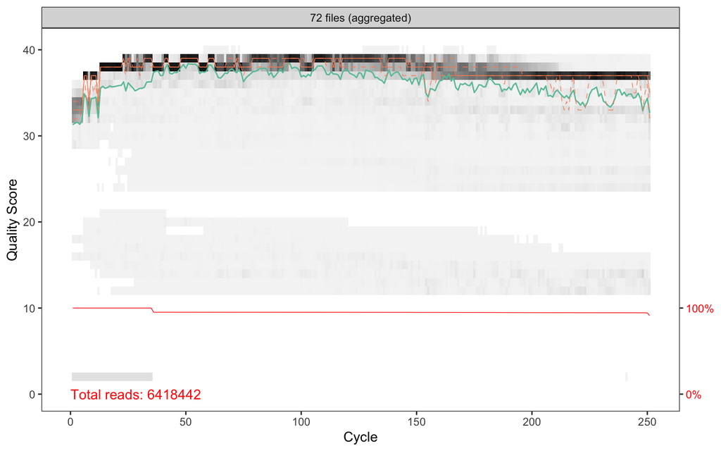

```r
# Generating initial forward and reverse read quality plots
initial_forward_qual<-plotQualityProfile(forwardreads_16s_phloem, aggregate=TRUE)
initial_forward_qual
```

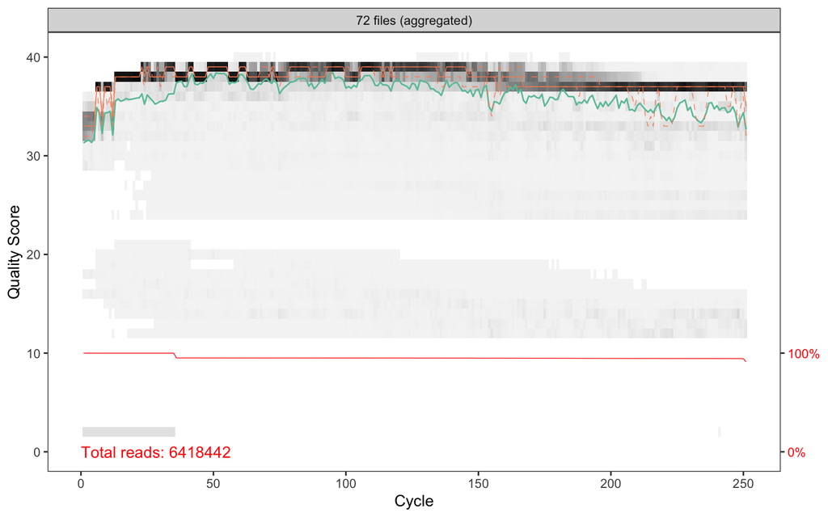

```r
initial_reverse_qual<-plotQualityProfile(forwardreads_16s_phloem, aggregate=TRUE)
initial_reverse_qual
```

# **Step 3: Filtering of Ambiguous Reads**

Removing reads with ambiguous bases.

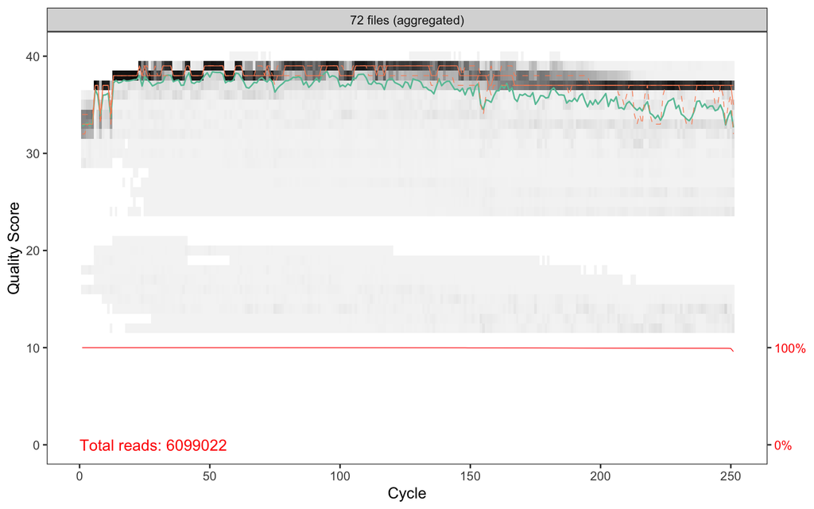

```r
# Creating an object  that strips away the pathway information leaving behind only the filename.
filebasename_16s_phloem<-basename(forwardreads_16s_phloem)

# Cleaning sample names to match with metadata sheet
basename_16s_phloem<-sub("-16s.*","",filebasename_16s_phloem)
treebasename_16s_phloem<-sub("phloem-","",basename_16s_phloem)
numericbasename_16s_phloem<-gsub("-","_",treebasename_16s_phloem)

# Creating an object that contains only our sample names.
samplenames_16s_phloem<-numericbasename_16s_phloem

# Creating two path objects that to store the paths for filtered forward and reverse reads.
forward.filtN_16s_phloem<-file.path(phloem_16s_path,"filtN",basename(forwardreads_16s_phloem))
reverse.filtN_16s_phloem<-file.path(phloem_16s_path,"filtN",basename(reversereads_16s_phloem))

# Filtering forward and reverse reads using the filterAndTrim function. Specifying maxN=0 will indicate that sequences with at least 1 ambiguous base will be removed from the dataset.
filterAndTrim(forwardreads_16s_phloem,forward.filtN_16s_phloem,reversereads_16s_phloem,reverse.filtN_16s_phloem,maxN=0)

# Creating quality profiles for the pre-filtered forward and reverse reads.
filtn_qualplot_fwd_16s_phloem<-plotQualityProfile(forward.filtN_16s_phloem, aggregate=TRUE)
filtn_qualplot_fwd_16s_phloem
```

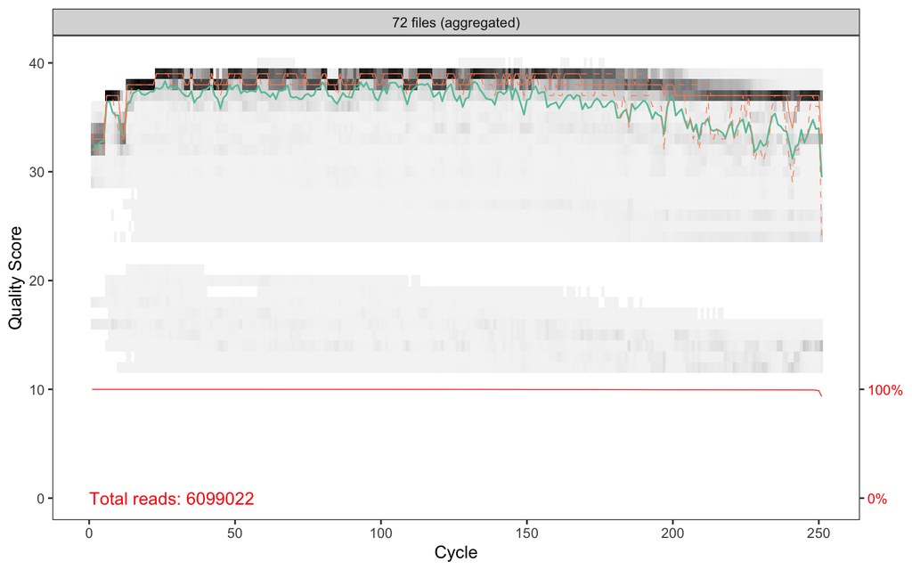

```r
filtn_qualplot_rev_16s_phloem<-plotQualityProfile(reverse.filtN_16s_phloem, aggregate=TRUE)
filtn_qualplot_rev_16s_phloem
```

# **Step 4: Primer Removal**

Removing primers used in the first step of PCR to amplify the V4 region. These are low diversity section that will not help with distinguishing between taxa.

```r
# Creating strings that contain the forward and reverse primers used in the study.
fwd1<-"GTGCCAGCMGCCGCGGTAA"
fwd2<- "GTGCCAGCMGCWGCGGTAA"
fwd3<- "GTGCCAGCMGCCGCGGTCA"
fwd4<- "GTGKCAGCMGCCGCGGTAA"
rev<- "GGACTACHVGGGTWTCTAAT"

# Creating a function called allorientations to identify all potenital orientations of the primers and using the complement, reverse, and reverseComplement functions to store all possible orientations of the primers in the orientations object). Using the sapply function to convert all orientations into individual strings of text.

allorientations<-function(primer){
  require(Biostrings)
  dna<-DNAString(primer)
  orientations<-c(Forward=dna, Complement=Biostrings::complement(dna),Reverse=Biostrings::reverse(dna),
             RevComp=Biostrings::reverseComplement(dna))
  return(sapply(orientations,toString))
}

# Storing all possible orientations of our primers in objects for each primer.
fwd1.ori<-allorientations(fwd1)
fwd2.ori<-allorientations(fwd2)
fwd3.ori<-allorientations(fwd3)
fwd4.ori<-allorientations(fwd4)
rev.ori<-allorientations(rev)



# Identifying occurences of the primers by creating a function called primeroccurences. This function will use the vcountPattern function which will return a vector containing the number of times a particular primer is detected in a sequence and the readFastq function which will take all fastq files in a particular director and turn them into a single object.
primeroccurences<-function(primer, directory) {
  nhits<-vcountPattern(primer, sread(readFastq(directory)),fixed=FALSE)
  return(sum(nhits>0))
}


# Using the sapply function to apply the primeroccurences function to the directories that contain the forward and reverse reads.The rbind function creates a table for each combination of primer and forward and reverse reads.
primertable_16s_phloem<-
  rbind(fwd1.forwardreads_16s_phloem=sapply(fwd1.ori,primeroccurences,directory=forward.filtN_16s_phloem),
      fwd1.reversereads_16s_phloem=sapply(fwd1.ori,primeroccurences,directory=reverse.filtN_16s_phloem),
      fwd2.forwardreads_16s_phloem=sapply(fwd2.ori,primeroccurences,directory=forward.filtN_16s_phloem),
      fwd2.reversereads_16s_phloem=sapply(fwd2.ori,primeroccurences,directory=reverse.filtN_16s_phloem),
      fwd3.forwardreads_16s_phloem=sapply(fwd3.ori,primeroccurences,directory=forward.filtN_16s_phloem),
      fwd3.reversereads_16s_phloem=sapply(fwd3.ori,primeroccurences,directory=reverse.filtN_16s_phloem),
      fwd4.forwardreads_16s_phloem=sapply(fwd4.ori,primeroccurences,directory=forward.filtN_16s_phloem),
      fwd4.reversereads_16s_phloem=sapply(fwd4.ori,primeroccurences,directory=reverse.filtN_16s_phloem),
      rev.forwardreads_16s_phloem=sapply(rev.ori,primeroccurences,directory=forward.filtN_16s_phloem),
      rev.reversereads_16s_phloem=sapply(rev.ori,primeroccurences,directory=reverse.filtN_16s_phloem))
primertable_16s_phloem
```

```
##                              Forward Complement Reverse RevComp
## fwd1.forwardreads_16s_phloem 2249298          0       0       0
## fwd1.reversereads_16s_phloem     950          0       0     470
## fwd2.forwardreads_16s_phloem  769891          0       0       0
## fwd2.reversereads_16s_phloem     258          0       0     166
## fwd3.forwardreads_16s_phloem    7233          0       0       0
## fwd3.reversereads_16s_phloem       0          0       0      55
## fwd4.forwardreads_16s_phloem 1275120          0       0       2
## fwd4.reversereads_16s_phloem     398          0       0     257
## rev.forwardreads_16s_phloem     1775          0       0    2790
## rev.reversereads_16s_phloem  5385120          0       0       1
```

```r
# Creating a directory to store the forward and reverse reads after they have been trimmed.
path.cut_16s_phloem<-file.path(phloem_16s_path,"cutadapt")
if(!dir.exists(path.cut_16s_phloem)) dir.create(path.cut_16s_phloem)

forwardreads.cut_16s_phloem<-file.path(path.cut_16s_phloem,basename(forwardreads_16s_phloem))
reversereads.cut_16s_phloem<-file.path(path.cut_16s_phloem,basename(reversereads_16s_phloem))

# Creating objects that contain the forward and reverse primer reverse compliment strings.  The rc function takes a sequence object provided by the user and creates the reverse compliment of the sequence.
fwd.rc1<-dada2:::rc(fwd1)
fwd.rc2<-dada2:::rc(fwd2)
fwd.rc3<-dada2:::rc(fwd3)
fwd.rc4<-dada2:::rc(fwd4)
rev.rc<-dada2:::rc(rev)

# Using the paste function to create objects that contain the flags for the potential combinations of each forward and reverse primer and the reverse compliment. These flags will serve as the arguments for cutadapt. The ^ at the beginning of the sequence indicates that the primer should be removed from the beginning of the sequence.
fwd1.r1.flags<-paste("-a"," ", "^", fwd1,"...",rev.rc, sep='')
fwd2.r1.flags<-paste("-a"," ", "^", fwd2,"...",rev.rc, sep='')
fwd3.r1.flags<-paste("-a"," ", "^", fwd3,"...",rev.rc, sep='')
fwd4.r1.flags<-paste("-a"," ", "^", fwd4,"...",rev.rc, sep='')
rev.fwd1.flags<-paste("-A"," ", "^", rev,"...",fwd.rc1, sep='')
rev.fwd2.flags<-paste("-A"," ", "^", rev,"...",fwd.rc2, sep='')
rev.fwd3.flags<-paste("-A"," ", "^", rev,"...",fwd.rc3, sep='')
rev.fwd4.flags<-paste("-A"," ", "^", rev,"...",fwd.rc4, sep='')

# Specifies the conda environment to use for cutadapt
use_condaenv(condaenv="/Users/aarononfurak/anaconda3/envs/cutadaptenv/bin/python")

# Using cutadapt to remove the primers from each read.
for (i in seq_along(forwardreads_16s_phloem)){
  system2("conda",args=c("run -n cutadaptenv cutadapt",
                          fwd1.r1.flags,
                          fwd2.r1.flags,
                          fwd3.r1.flags,
                          fwd4.r1.flags,
                          rev.fwd1.flags,
                          rev.fwd2.flags,
                          rev.fwd3.flags,
                          rev.fwd4.flags,
                          "--discard-untrimmed","--minimum-length",10, "--report=minimal",
                          "-o",forwardreads.cut_16s_phloem[i], "-p",reversereads.cut_16s_phloem[i],
                          forward.filtN_16s_phloem[i],reverse.filtN_16s_phloem[i]))
}

# Last we evaluate the efficacy of our primer removal with cutadapt using the primeroccurrences function.
primertable2_16s_phloem<-
 rbind(fwd1.forwardreads_16s_phloem=sapply(fwd1.ori,primeroccurences,directory=forwardreads.cut_16s_phloem),
      fwd1.reversereads_16s_phloem=sapply(fwd1.ori,primeroccurences,directory=reversereads.cut_16s_phloem),
      fwd2.forwardreads_16s_phloem=sapply(fwd2.ori,primeroccurences,directory=forwardreads.cut_16s_phloem),
      fwd2.reversereads_16s_phloem=sapply(fwd2.ori,primeroccurences,directory=reversereads.cut_16s_phloem),
      fwd3.forwardreads_16s_phloem=sapply(fwd3.ori,primeroccurences,directory=forwardreads.cut_16s_phloem),
      fwd3.reversereads_16s_phloem=sapply(fwd3.ori,primeroccurences,directory=reversereads.cut_16s_phloem),
      fwd4.forwardreads_16s_phloem=sapply(fwd4.ori,primeroccurences,directory=forwardreads.cut_16s_phloem),
      fwd4.reversereads_16s_phloem=sapply(fwd4.ori,primeroccurences,directory=reversereads.cut_16s_phloem),
      rev.forwardreads_16s_phloem=sapply(rev.ori,primeroccurences,directory=forwardreads.cut_16s_phloem),
      rev.reversereads_16s_phloem=sapply(rev.ori,primeroccurences,directory=reversereads.cut_16s_phloem))

primertable2_16s_phloem
```

```
##                              Forward Complement Reverse RevComp
## fwd1.forwardreads_16s_phloem       3          0       0       0
## fwd1.reversereads_16s_phloem       0          0       0       0
## fwd2.forwardreads_16s_phloem       1          0       0       0
## fwd2.reversereads_16s_phloem       0          0       0       0
## fwd3.forwardreads_16s_phloem       0          0       0       0
## fwd3.reversereads_16s_phloem       0          0       0       0
## fwd4.forwardreads_16s_phloem       0          0       0       0
## fwd4.reversereads_16s_phloem       0          0       0       0
## rev.forwardreads_16s_phloem        0          0       0       0
## rev.reversereads_16s_phloem       20          0       0       0
```

```r
# Comparing the pre vs post primer detections.
primertable_16s_phloem
```

```
##                              Forward Complement Reverse RevComp
## fwd1.forwardreads_16s_phloem 2249298          0       0       0
## fwd1.reversereads_16s_phloem     950          0       0     470
## fwd2.forwardreads_16s_phloem  769891          0       0       0
## fwd2.reversereads_16s_phloem     258          0       0     166
## fwd3.forwardreads_16s_phloem    7233          0       0       0
## fwd3.reversereads_16s_phloem       0          0       0      55
## fwd4.forwardreads_16s_phloem 1275120          0       0       2
## fwd4.reversereads_16s_phloem     398          0       0     257
## rev.forwardreads_16s_phloem     1775          0       0    2790
## rev.reversereads_16s_phloem  5385120          0       0       1
```

```r
primertable2_16s_phloem
```

```
##                              Forward Complement Reverse RevComp
## fwd1.forwardreads_16s_phloem       3          0       0       0
## fwd1.reversereads_16s_phloem       0          0       0       0
## fwd2.forwardreads_16s_phloem       1          0       0       0
## fwd2.reversereads_16s_phloem       0          0       0       0
## fwd3.forwardreads_16s_phloem       0          0       0       0
## fwd3.reversereads_16s_phloem       0          0       0       0
## fwd4.forwardreads_16s_phloem       0          0       0       0
## fwd4.reversereads_16s_phloem       0          0       0       0
## rev.forwardreads_16s_phloem        0          0       0       0
## rev.reversereads_16s_phloem       20          0       0       0
```

# **Step 5: Quality Filtering**

Quality filtering data prior to denoising with dada2. Generating quality plots for the sequences that have had their primers removed and use these quality plots to determine what parameters should be used to filter sequences.

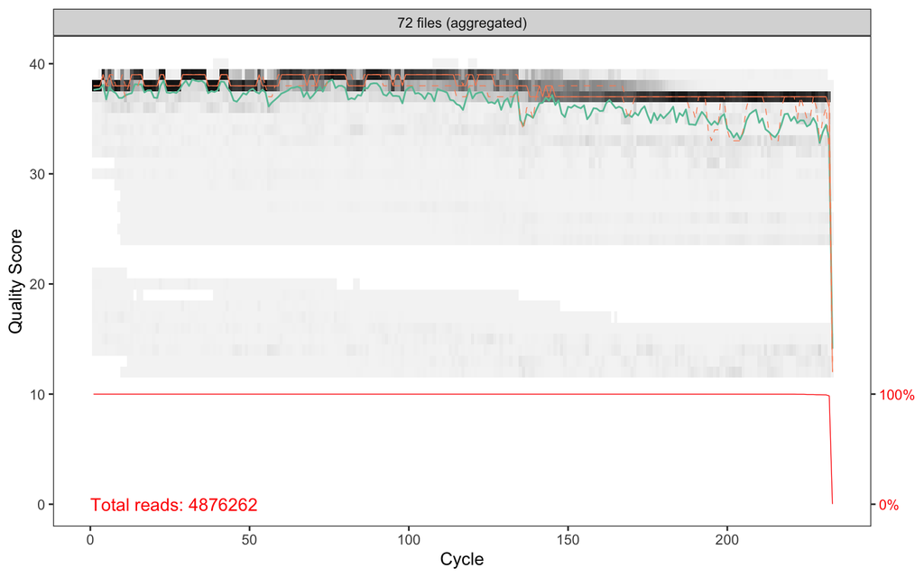

```r
# Creating new pathways for the quality filtered forward and reverse reads.
filtforward_16s_phloem<-file.path(phloem_16s_path, "filtered", paste0(samplenames_16s_phloem,"_F_filt.fastq.gz"))
filtreverse_16s_phloem<-file.path(phloem_16s_path,"filtered",paste0(samplenames_16s_phloem,"_R_filt.fastq.gz"))

# Assigning names to each pathway to more easily refer to the paths. These names are based on the sample names of each file.
names(filtforward_16s_phloem)<-samplenames_16s_phloem
names(filtreverse_16s_phloem)<-samplenames_16s_phloem

# Generating quality plots for the forward and reverse reads that have had their primers removed with cutadapt.
cut_qualplot_fwd_16s_phloem<-plotQualityProfile(forwardreads.cut_16s_phloem, aggregate=TRUE)
cut_qualplot_fwd_16s_phloem
```

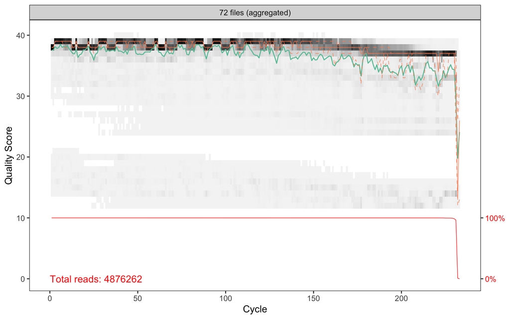

```r
cut_qualplot_rev_16s_phloem<-plotQualityProfile(reversereads.cut_16s_phloem, aggregate=TRUE)
cut_qualplot_rev_16s_phloem
```

```r
# Quality filtering reads
filter.out_16s_phloem<-filterAndTrim(fwd=forwardreads.cut_16s_phloem, filt=filtforward_16s_phloem, rev=reversereads.cut_16s_phloem, filt.rev=filtreverse_16s_phloem, maxN=0, maxEE=c(2,2), truncLen = 225, compress=TRUE, multithread = FALSE)

# Converting quality filtered object to a data fram
filter.out_16s_phloem<-as.data.frame(filter.out_16s_phloem)

# Examining effects of quality filtering
filter.out_16s_phloem$diffs <- filter.out_16s_phloem$reads.in-filter.out_16s_phloem$reads.out
filter.out_16s_phloem[order(filter.out_16s_phloem$diffs),]
```

```
##                                             reads.in reads.out diffs
## phloem-tree-70-16s_S64_L001_R1_001.fastq.gz     4758      4230   528
## phloem-tree-19-16s_S73_L001_R1_001.fastq.gz    10859      9691  1168
## phloem-tree-40-16s_S32_L001_R1_001.fastq.gz    12268     11069  1199
## phloem-tree-72-16s_S35_L001_R1_001.fastq.gz    12389     11178  1211
## phloem-tree-29-16s_S70_L001_R1_001.fastq.gz    12521     11144  1377
## phloem-tree-18-16s_S59_L001_R1_001.fastq.gz    16264     14812  1452
## phloem-tree-25-16s_S16_L001_R1_001.fastq.gz    14085     12349  1736
## phloem-tree-16-16s_S68_L001_R1_001.fastq.gz    22654     20734  1920
## phloem-tree-59-16s_S31_L001_R1_001.fastq.gz    25235     23260  1975
## phloem-tree-33-16s_S50_L001_R1_001.fastq.gz    38254     36156  2098
## phloem-tree-43-16s_S44_L001_R1_001.fastq.gz    44486     41983  2503
## phloem-tree-58-16s_S25_L001_R1_001.fastq.gz    24445     21673  2772
## phloem-tree-15-16s_S72_L001_R1_001.fastq.gz    48890     45993  2897
## phloem-tree-30-16s_S5_L001_R1_001.fastq.gz     45880     42832  3048
## phloem-tree-63-16s_S7_L001_R1_001.fastq.gz     55589     52484  3105
## phloem-tree-67-16s_S45_L001_R1_001.fastq.gz    56630     53376  3254
## phloem-tree-21-16s_S14_L001_R1_001.fastq.gz    49608     46205  3403
## phloem-tree-39-16s_S58_L001_R1_001.fastq.gz    53246     49819  3427
## phloem-tree-27-16s_S12_L001_R1_001.fastq.gz    54990     51534  3456
## phloem-tree-66-16s_S40_L001_R1_001.fastq.gz    64327     60791  3536
## phloem-tree-64-16s_S65_L001_R1_001.fastq.gz    75854     72305  3549
## phloem-tree-34-16s_S36_L001_R1_001.fastq.gz    37791     34167  3624
## phloem-tree-46-16s_S15_L001_R1_001.fastq.gz    37603     33935  3668
## phloem-tree-44-16s_S48_L001_R1_001.fastq.gz    55411     51654  3757
## phloem-tree-57-16s_S46_L001_R1_001.fastq.gz    59937     56075  3862
## phloem-tree-10-16s_S56_L001_R1_001.fastq.gz    40613     36529  4084
## phloem-tree-52-16s_S47_L001_R1_001.fastq.gz    49954     45832  4122
## phloem-tree-69-16s_S55_L001_R1_001.fastq.gz    71284     67137  4147
## phloem-tree-50-16s_S42_L001_R1_001.fastq.gz    39402     35208  4194
## phloem-tree-61-16s_S8_L001_R1_001.fastq.gz     80904     76646  4258
## phloem-tree-45-16s_S26_L001_R1_001.fastq.gz    39397     35108  4289
## phloem-tree-4-16s_S61_L001_R1_001.fastq.gz     66712     62391  4321
## phloem-tree-11-16s_S43_L001_R1_001.fastq.gz    32721     28254  4467
## phloem-tree-60-16s_S27_L001_R1_001.fastq.gz    86096     81613  4483
## phloem-tree-6-16s_S19_L001_R1_001.fastq.gz     44085     39586  4499
## phloem-tree-48-16s_S9_L001_R1_001.fastq.gz     79851     75166  4685
## phloem-tree-55-16s_S57_L001_R1_001.fastq.gz    70414     65704  4710
## phloem-tree-42-16s_S28_L001_R1_001.fastq.gz    87320     82533  4787
## phloem-tree-56-16s_S66_L001_R1_001.fastq.gz    59959     54976  4983
```

[output cut: 18 more lines]

```
## phloem-tree-7-16s_S13_L001_R1_001.fastq.gz     94390     88075  6315
## phloem-tree-8-16s_S17_L001_R1_001.fastq.gz     97771     91454  6317
## phloem-tree-3-16s_S23_L001_R1_001.fastq.gz     62069     55635  6434
## phloem-tree-12-16s_S74_L001_R1_001.fastq.gz    56678     49915  6763
## phloem-tree-2-16s_S71_L001_R1_001.fastq.gz    114461    107636  6825
## phloem-tree-31-16s_S34_L001_R1_001.fastq.gz   146098    139085  7013
## phloem-tree-9-16s_S11_L001_R1_001.fastq.gz    115551    107927  7624
## phloem-tree-62-16s_S62_L001_R1_001.fastq.gz   129609    121843  7766
## phloem-tree-68-16s_S53_L001_R1_001.fastq.gz    67752     59948  7804
## phloem-tree-47-16s_S63_L001_R1_001.fastq.gz   178467    170497  7970
## phloem-tree-32-16s_S24_L001_R1_001.fastq.gz   102359     94373  7986
## phloem-tree-49-16s_S39_L001_R1_001.fastq.gz   144245    136201  8044
## phloem-tree-5-16s_S18_L001_R1_001.fastq.gz     81457     69618 11839
## phloem-tree-13-16s_S2_L001_R1_001.fastq.gz    199753    187570 12183
## phloem-tree-14-16s_S54_L001_R1_001.fastq.gz   153761    141133 12628
```

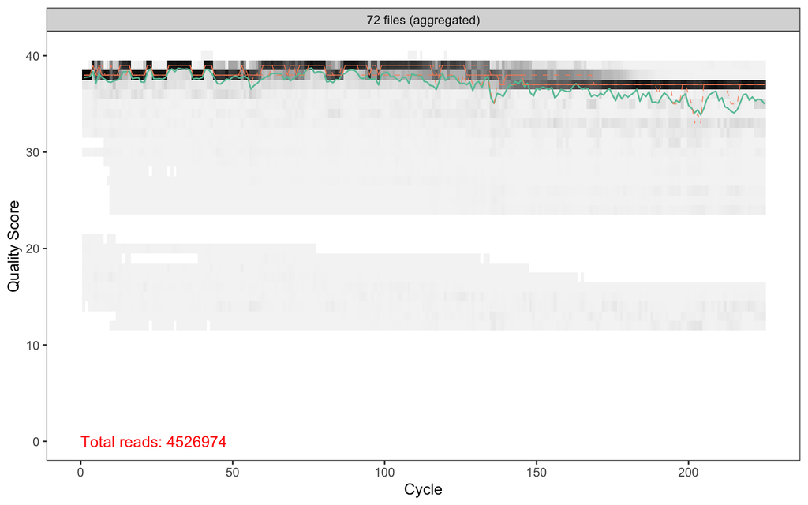

```r
# Generating quality plots for the forward and reverse reads after quality filtering
filtered_qualplot_fwd_16s_phloem<-plotQualityProfile(filtforward_16s_phloem, aggregate=TRUE)
filtered_qualplot_fwd_16s_phloem
```

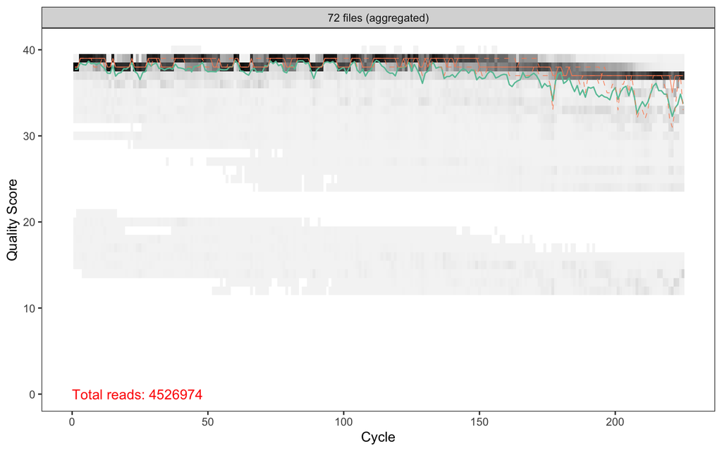

```r
filtered_qualplot_rev_16s_phloem<-plotQualityProfile(filtreverse_16s_phloem, aggregate=TRUE)
filtered_qualplot_rev_16s_phloem
```

## **Step 6: Learn Error Rates**

Learning the error rates of the data.

```r
# Learning errors for forward and reverse reads.
errorforward_16s_phloem<-learnErrors(filtforward_16s_phloem, multithread = TRUE)
```

```
## 114326775 total bases in 508119 reads from 6 samples will be used for learning the error rates.
```

```r
errorreverse_16s_phloem<-learnErrors(filtreverse_16s_phloem,multithread = TRUE)
```

```
## 114326775 total bases in 508119 reads from 6 samples will be used for learning the error rates.
```

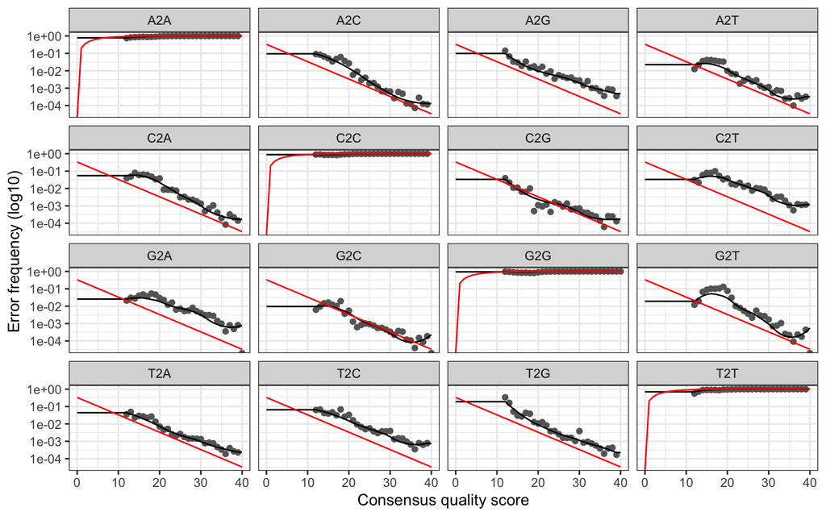

```r
# Error plots for forward & reverse reads
errplots_fwd_16s_phloem<-plotErrors(errorforward_16s_phloem, nominalQ=TRUE)
errplots_fwd_16s_phloem
```

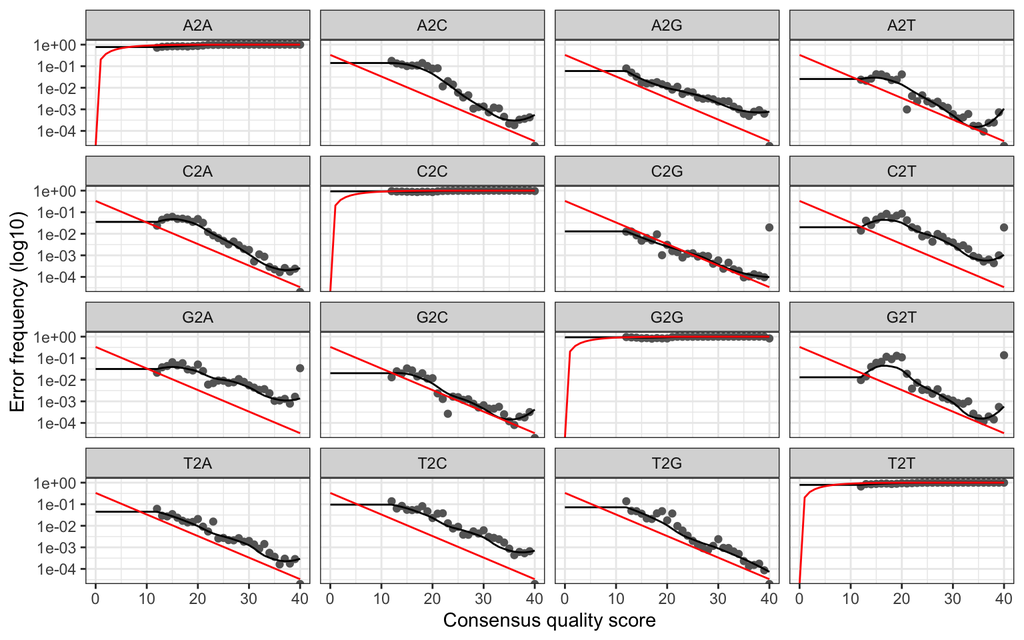

```r
errplots_rev_16s_phloem<-plotErrors(errorreverse_16s_phloem,nominalQ = TRUE)
errplots_rev_16s_phloem
```

# **Step 7: Dereplication**

Dereplicating duplicate reads

```r
# Dereplicating reads
derepforward_16s_phloem<-derepFastq(filtforward_16s_phloem,verbose=TRUE)
```

```
## Dereplicating sequence entries in Fastq file: /Volumes/control_experiments/phosphojet_and_rootshield_experiments_summer_2020/nursery_summer_2020/phloem_bacteria_ornl_jnigrarnaseq_su20_ajo_v2/sequence_processing/filtered/tree_1_F_filt.fastq.gz
```

```
## Encountered 9392 unique sequences from 64718 total sequences read.
```

```
## Dereplicating sequence entries in Fastq file: /Volumes/control_experiments/phosphojet_and_rootshield_experiments_summer_2020/nursery_summer_2020/phloem_bacteria_ornl_jnigrarnaseq_su20_ajo_v2/sequence_processing/filtered/tree_10_F_filt.fastq.gz
```

```
## Encountered 7870 unique sequences from 36529 total sequences read.
```

```
## Dereplicating sequence entries in Fastq file: /Volumes/control_experiments/phosphojet_and_rootshield_experiments_summer_2020/nursery_summer_2020/phloem_bacteria_ornl_jnigrarnaseq_su20_ajo_v2/sequence_processing/filtered/tree_11_F_filt.fastq.gz
```

```
## Encountered 5620 unique sequences from 28254 total sequences read.
```

```
## Dereplicating sequence entries in Fastq file: /Volumes/control_experiments/phosphojet_and_rootshield_experiments_summer_2020/nursery_summer_2020/phloem_bacteria_ornl_jnigrarnaseq_su20_ajo_v2/sequence_processing/filtered/tree_12_F_filt.fastq.gz
```

```
## Encountered 12465 unique sequences from 49915 total sequences read.
```

```
## Dereplicating sequence entries in Fastq file: /Volumes/control_experiments/phosphojet_and_rootshield_experiments_summer_2020/nursery_summer_2020/phloem_bacteria_ornl_jnigrarnaseq_su20_ajo_v2/sequence_processing/filtered/tree_13_F_filt.fastq.gz
```

```
## Encountered 21988 unique sequences from 187570 total sequences read.
```

```
## Dereplicating sequence entries in Fastq file: /Volumes/control_experiments/phosphojet_and_rootshield_experiments_summer_2020/nursery_summer_2020/phloem_bacteria_ornl_jnigrarnaseq_su20_ajo_v2/sequence_processing/filtered/tree_14_F_filt.fastq.gz
```

```
## Encountered 25308 unique sequences from 141133 total sequences read.
```

```
## Dereplicating sequence entries in Fastq file: /Volumes/control_experiments/phosphojet_and_rootshield_experiments_summer_2020/nursery_summer_2020/phloem_bacteria_ornl_jnigrarnaseq_su20_ajo_v2/sequence_processing/filtered/tree_15_F_filt.fastq.gz
```

```
## Encountered 4527 unique sequences from 45993 total sequences read.
```

```
## Dereplicating sequence entries in Fastq file: /Volumes/control_experiments/phosphojet_and_rootshield_experiments_summer_2020/nursery_summer_2020/phloem_bacteria_ornl_jnigrarnaseq_su20_ajo_v2/sequence_processing/filtered/tree_16_F_filt.fastq.gz
```

```
## Encountered 3042 unique sequences from 20734 total sequences read.
```

```
## Dereplicating sequence entries in Fastq file: /Volumes/control_experiments/phosphojet_and_rootshield_experiments_summer_2020/nursery_summer_2020/phloem_bacteria_ornl_jnigrarnaseq_su20_ajo_v2/sequence_processing/filtered/tree_17_F_filt.fastq.gz
```

```
## Encountered 5253 unique sequences from 30560 total sequences read.
```

```
## Dereplicating sequence entries in Fastq file: /Volumes/control_experiments/phosphojet_and_rootshield_experiments_summer_2020/nursery_summer_2020/phloem_bacteria_ornl_jnigrarnaseq_su20_ajo_v2/sequence_processing/filtered/tree_18_F_filt.fastq.gz
```

```
## Encountered 3114 unique sequences from 14812 total sequences read.
```

```
## Dereplicating sequence entries in Fastq file: /Volumes/control_experiments/phosphojet_and_rootshield_experiments_summer_2020/nursery_summer_2020/phloem_bacteria_ornl_jnigrarnaseq_su20_ajo_v2/sequence_processing/filtered/tree_19_F_filt.fastq.gz
```

```
## Encountered 2451 unique sequences from 9691 total sequences read.
```

```
## Dereplicating sequence entries in Fastq file: /Volumes/control_experiments/phosphojet_and_rootshield_experiments_summer_2020/nursery_summer_2020/phloem_bacteria_ornl_jnigrarnaseq_su20_ajo_v2/sequence_processing/filtered/tree_2_F_filt.fastq.gz
```

```
## Encountered 12813 unique sequences from 107636 total sequences read.
```

```
## Dereplicating sequence entries in Fastq file: /Volumes/control_experiments/phosphojet_and_rootshield_experiments_summer_2020/nursery_summer_2020/phloem_bacteria_ornl_jnigrarnaseq_su20_ajo_v2/sequence_processing/filtered/tree_20_F_filt.fastq.gz
```

```
## Encountered 8403 unique sequences from 78071 total sequences read.
```

```
## Dereplicating sequence entries in Fastq file: /Volumes/control_experiments/phosphojet_and_rootshield_experiments_summer_2020/nursery_summer_2020/phloem_bacteria_ornl_jnigrarnaseq_su20_ajo_v2/sequence_processing/filtered/tree_21_F_filt.fastq.gz
```

```
## Encountered 7670 unique sequences from 46205 total sequences read.
```

```
## Dereplicating sequence entries in Fastq file: /Volumes/control_experiments/phosphojet_and_rootshield_experiments_summer_2020/nursery_summer_2020/phloem_bacteria_ornl_jnigrarnaseq_su20_ajo_v2/sequence_processing/filtered/tree_22_F_filt.fastq.gz
```

```
## Encountered 10747 unique sequences from 102830 total sequences read.
```

```
## Dereplicating sequence entries in Fastq file: /Volumes/control_experiments/phosphojet_and_rootshield_experiments_summer_2020/nursery_summer_2020/phloem_bacteria_ornl_jnigrarnaseq_su20_ajo_v2/sequence_processing/filtered/tree_23_F_filt.fastq.gz
```

```
## Encountered 10272 unique sequences from 91671 total sequences read.
```

```
## Dereplicating sequence entries in Fastq file: /Volumes/control_experiments/phosphojet_and_rootshield_experiments_summer_2020/nursery_summer_2020/phloem_bacteria_ornl_jnigrarnaseq_su20_ajo_v2/sequence_processing/filtered/tree_24_F_filt.fastq.gz
```

```
## Encountered 9790 unique sequences from 75879 total sequences read.
```

```
## Dereplicating sequence entries in Fastq file: /Volumes/control_experiments/phosphojet_and_rootshield_experiments_summer_2020/nursery_summer_2020/phloem_bacteria_ornl_jnigrarnaseq_su20_ajo_v2/sequence_processing/filtered/tree_25_F_filt.fastq.gz
```

```
## Encountered 2706 unique sequences from 12349 total sequences read.
```

```
## Dereplicating sequence entries in Fastq file: /Volumes/control_experiments/phosphojet_and_rootshield_experiments_summer_2020/nursery_summer_2020/phloem_bacteria_ornl_jnigrarnaseq_su20_ajo_v2/sequence_processing/filtered/tree_26_F_filt.fastq.gz
```

```
## Encountered 9071 unique sequences from 54513 total sequences read.
```

```
## Dereplicating sequence entries in Fastq file: /Volumes/control_experiments/phosphojet_and_rootshield_experiments_summer_2020/nursery_summer_2020/phloem_bacteria_ornl_jnigrarnaseq_su20_ajo_v2/sequence_processing/filtered/tree_27_F_filt.fastq.gz
```

```
## Encountered 7042 unique sequences from 51534 total sequences read.
```

```
## Dereplicating sequence entries in Fastq file: /Volumes/control_experiments/phosphojet_and_rootshield_experiments_summer_2020/nursery_summer_2020/phloem_bacteria_ornl_jnigrarnaseq_su20_ajo_v2/sequence_processing/filtered/tree_28_F_filt.fastq.gz
```

```
## Encountered 10869 unique sequences from 54462 total sequences read.
```

```
## Dereplicating sequence entries in Fastq file: /Volumes/control_experiments/phosphojet_and_rootshield_experiments_summer_2020/nursery_summer_2020/phloem_bacteria_ornl_jnigrarnaseq_su20_ajo_v2/sequence_processing/filtered/tree_29_F_filt.fastq.gz
```

```
## Encountered 2516 unique sequences from 11144 total sequences read.
```

```
## Dereplicating sequence entries in Fastq file: /Volumes/control_experiments/phosphojet_and_rootshield_experiments_summer_2020/nursery_summer_2020/phloem_bacteria_ornl_jnigrarnaseq_su20_ajo_v2/sequence_processing/filtered/tree_3_F_filt.fastq.gz
```

```
## Encountered 8361 unique sequences from 55635 total sequences read.
```

```
## Dereplicating sequence entries in Fastq file: /Volumes/control_experiments/phosphojet_and_rootshield_experiments_summer_2020/nursery_summer_2020/phloem_bacteria_ornl_jnigrarnaseq_su20_ajo_v2/sequence_processing/filtered/tree_30_F_filt.fastq.gz
```

```
## Encountered 6681 unique sequences from 42832 total sequences read.
```

```
## Dereplicating sequence entries in Fastq file: /Volumes/control_experiments/phosphojet_and_rootshield_experiments_summer_2020/nursery_summer_2020/phloem_bacteria_ornl_jnigrarnaseq_su20_ajo_v2/sequence_processing/filtered/tree_31_F_filt.fastq.gz
```

```
## Encountered 14665 unique sequences from 139085 total sequences read.
```

```
## Dereplicating sequence entries in Fastq file: /Volumes/control_experiments/phosphojet_and_rootshield_experiments_summer_2020/nursery_summer_2020/phloem_bacteria_ornl_jnigrarnaseq_su20_ajo_v2/sequence_processing/filtered/tree_32_F_filt.fastq.gz
```

```
## Encountered 11551 unique sequences from 94373 total sequences read.
```

```
## Dereplicating sequence entries in Fastq file: /Volumes/control_experiments/phosphojet_and_rootshield_experiments_summer_2020/nursery_summer_2020/phloem_bacteria_ornl_jnigrarnaseq_su20_ajo_v2/sequence_processing/filtered/tree_33_F_filt.fastq.gz
```

```
## Encountered 5193 unique sequences from 36156 total sequences read.
```

```
## Dereplicating sequence entries in Fastq file: /Volumes/control_experiments/phosphojet_and_rootshield_experiments_summer_2020/nursery_summer_2020/phloem_bacteria_ornl_jnigrarnaseq_su20_ajo_v2/sequence_processing/filtered/tree_34_F_filt.fastq.gz
```

```
## Encountered 6494 unique sequences from 34167 total sequences read.
```

```
## Dereplicating sequence entries in Fastq file: /Volumes/control_experiments/phosphojet_and_rootshield_experiments_summer_2020/nursery_summer_2020/phloem_bacteria_ornl_jnigrarnaseq_su20_ajo_v2/sequence_processing/filtered/tree_35_F_filt.fastq.gz
```

```
## Encountered 9280 unique sequences from 85674 total sequences read.
```

```
## Dereplicating sequence entries in Fastq file: /Volumes/control_experiments/phosphojet_and_rootshield_experiments_summer_2020/nursery_summer_2020/phloem_bacteria_ornl_jnigrarnaseq_su20_ajo_v2/sequence_processing/filtered/tree_36_F_filt.fastq.gz
```

```
## Encountered 8515 unique sequences from 99204 total sequences read.
```

```
## Dereplicating sequence entries in Fastq file: /Volumes/control_experiments/phosphojet_and_rootshield_experiments_summer_2020/nursery_summer_2020/phloem_bacteria_ornl_jnigrarnaseq_su20_ajo_v2/sequence_processing/filtered/tree_37_F_filt.fastq.gz
```

```
## Encountered 8136 unique sequences from 47660 total sequences read.
```

```
## Dereplicating sequence entries in Fastq file: /Volumes/control_experiments/phosphojet_and_rootshield_experiments_summer_2020/nursery_summer_2020/phloem_bacteria_ornl_jnigrarnaseq_su20_ajo_v2/sequence_processing/filtered/tree_38_F_filt.fastq.gz
```

```
## Encountered 6914 unique sequences from 38933 total sequences read.
```

```
## Dereplicating sequence entries in Fastq file: /Volumes/control_experiments/phosphojet_and_rootshield_experiments_summer_2020/nursery_summer_2020/phloem_bacteria_ornl_jnigrarnaseq_su20_ajo_v2/sequence_processing/filtered/tree_39_F_filt.fastq.gz
```

```
## Encountered 7233 unique sequences from 49819 total sequences read.
```

```
## Dereplicating sequence entries in Fastq file: /Volumes/control_experiments/phosphojet_and_rootshield_experiments_summer_2020/nursery_summer_2020/phloem_bacteria_ornl_jnigrarnaseq_su20_ajo_v2/sequence_processing/filtered/tree_4_F_filt.fastq.gz
```

```
## Encountered 8801 unique sequences from 62391 total sequences read.
```

```
## Dereplicating sequence entries in Fastq file: /Volumes/control_experiments/phosphojet_and_rootshield_experiments_summer_2020/nursery_summer_2020/phloem_bacteria_ornl_jnigrarnaseq_su20_ajo_v2/sequence_processing/filtered/tree_40_F_filt.fastq.gz
```

```
## Encountered 2671 unique sequences from 11069 total sequences read.
```

```
## Dereplicating sequence entries in Fastq file: /Volumes/control_experiments/phosphojet_and_rootshield_experiments_summer_2020/nursery_summer_2020/phloem_bacteria_ornl_jnigrarnaseq_su20_ajo_v2/sequence_processing/filtered/tree_41_F_filt.fastq.gz
```

```
## Encountered 9410 unique sequences from 78844 total sequences read.
```

```
## Dereplicating sequence entries in Fastq file: /Volumes/control_experiments/phosphojet_and_rootshield_experiments_summer_2020/nursery_summer_2020/phloem_bacteria_ornl_jnigrarnaseq_su20_ajo_v2/sequence_processing/filtered/tree_42_F_filt.fastq.gz
```

```
## Encountered 8700 unique sequences from 82533 total sequences read.
```

```
## Dereplicating sequence entries in Fastq file: /Volumes/control_experiments/phosphojet_and_rootshield_experiments_summer_2020/nursery_summer_2020/phloem_bacteria_ornl_jnigrarnaseq_su20_ajo_v2/sequence_processing/filtered/tree_43_F_filt.fastq.gz
```

```
## Encountered 3495 unique sequences from 41983 total sequences read.
```

```
## Dereplicating sequence entries in Fastq file: /Volumes/control_experiments/phosphojet_and_rootshield_experiments_summer_2020/nursery_summer_2020/phloem_bacteria_ornl_jnigrarnaseq_su20_ajo_v2/sequence_processing/filtered/tree_44_F_filt.fastq.gz
```

```
## Encountered 8845 unique sequences from 51654 total sequences read.
```

```
## Dereplicating sequence entries in Fastq file: /Volumes/control_experiments/phosphojet_and_rootshield_experiments_summer_2020/nursery_summer_2020/phloem_bacteria_ornl_jnigrarnaseq_su20_ajo_v2/sequence_processing/filtered/tree_45_F_filt.fastq.gz
```

```
## Encountered 6031 unique sequences from 35108 total sequences read.
```

```
## Dereplicating sequence entries in Fastq file: /Volumes/control_experiments/phosphojet_and_rootshield_experiments_summer_2020/nursery_summer_2020/phloem_bacteria_ornl_jnigrarnaseq_su20_ajo_v2/sequence_processing/filtered/tree_46_F_filt.fastq.gz
```

```
## Encountered 6649 unique sequences from 33935 total sequences read.
```

```
## Dereplicating sequence entries in Fastq file: /Volumes/control_experiments/phosphojet_and_rootshield_experiments_summer_2020/nursery_summer_2020/phloem_bacteria_ornl_jnigrarnaseq_su20_ajo_v2/sequence_processing/filtered/tree_47_F_filt.fastq.gz
```

```
## Encountered 14945 unique sequences from 170497 total sequences read.
```

```
## Dereplicating sequence entries in Fastq file: /Volumes/control_experiments/phosphojet_and_rootshield_experiments_summer_2020/nursery_summer_2020/phloem_bacteria_ornl_jnigrarnaseq_su20_ajo_v2/sequence_processing/filtered/tree_48_F_filt.fastq.gz
```

```
## Encountered 9743 unique sequences from 75166 total sequences read.
```

```
## Dereplicating sequence entries in Fastq file: /Volumes/control_experiments/phosphojet_and_rootshield_experiments_summer_2020/nursery_summer_2020/phloem_bacteria_ornl_jnigrarnaseq_su20_ajo_v2/sequence_processing/filtered/tree_49_F_filt.fastq.gz
```

```
## Encountered 14945 unique sequences from 136201 total sequences read.
```

```
## Dereplicating sequence entries in Fastq file: /Volumes/control_experiments/phosphojet_and_rootshield_experiments_summer_2020/nursery_summer_2020/phloem_bacteria_ornl_jnigrarnaseq_su20_ajo_v2/sequence_processing/filtered/tree_5_F_filt.fastq.gz
```

```
## Encountered 13690 unique sequences from 69618 total sequences read.
```

```
## Dereplicating sequence entries in Fastq file: /Volumes/control_experiments/phosphojet_and_rootshield_experiments_summer_2020/nursery_summer_2020/phloem_bacteria_ornl_jnigrarnaseq_su20_ajo_v2/sequence_processing/filtered/tree_50_F_filt.fastq.gz
```

```
## Encountered 5862 unique sequences from 35208 total sequences read.
```

```
## Dereplicating sequence entries in Fastq file: /Volumes/control_experiments/phosphojet_and_rootshield_experiments_summer_2020/nursery_summer_2020/phloem_bacteria_ornl_jnigrarnaseq_su20_ajo_v2/sequence_processing/filtered/tree_51_F_filt.fastq.gz
```

```
## Encountered 7366 unique sequences from 57898 total sequences read.
```

```
## Dereplicating sequence entries in Fastq file: /Volumes/control_experiments/phosphojet_and_rootshield_experiments_summer_2020/nursery_summer_2020/phloem_bacteria_ornl_jnigrarnaseq_su20_ajo_v2/sequence_processing/filtered/tree_52_F_filt.fastq.gz
```

```
## Encountered 6846 unique sequences from 45832 total sequences read.
```

```
## Dereplicating sequence entries in Fastq file: /Volumes/control_experiments/phosphojet_and_rootshield_experiments_summer_2020/nursery_summer_2020/phloem_bacteria_ornl_jnigrarnaseq_su20_ajo_v2/sequence_processing/filtered/tree_53_F_filt.fastq.gz
```

```
## Encountered 7915 unique sequences from 46737 total sequences read.
```

```
## Dereplicating sequence entries in Fastq file: /Volumes/control_experiments/phosphojet_and_rootshield_experiments_summer_2020/nursery_summer_2020/phloem_bacteria_ornl_jnigrarnaseq_su20_ajo_v2/sequence_processing/filtered/tree_54_F_filt.fastq.gz
```

```
## Encountered 9378 unique sequences from 81772 total sequences read.
```

```
## Dereplicating sequence entries in Fastq file: /Volumes/control_experiments/phosphojet_and_rootshield_experiments_summer_2020/nursery_summer_2020/phloem_bacteria_ornl_jnigrarnaseq_su20_ajo_v2/sequence_processing/filtered/tree_55_F_filt.fastq.gz
```

```
## Encountered 10224 unique sequences from 65704 total sequences read.
```

```
## Dereplicating sequence entries in Fastq file: /Volumes/control_experiments/phosphojet_and_rootshield_experiments_summer_2020/nursery_summer_2020/phloem_bacteria_ornl_jnigrarnaseq_su20_ajo_v2/sequence_processing/filtered/tree_56_F_filt.fastq.gz
```

```
## Encountered 10035 unique sequences from 54976 total sequences read.
```

```
## Dereplicating sequence entries in Fastq file: /Volumes/control_experiments/phosphojet_and_rootshield_experiments_summer_2020/nursery_summer_2020/phloem_bacteria_ornl_jnigrarnaseq_su20_ajo_v2/sequence_processing/filtered/tree_57_F_filt.fastq.gz
```

```
## Encountered 7257 unique sequences from 56075 total sequences read.
```

```
## Dereplicating sequence entries in Fastq file: /Volumes/control_experiments/phosphojet_and_rootshield_experiments_summer_2020/nursery_summer_2020/phloem_bacteria_ornl_jnigrarnaseq_su20_ajo_v2/sequence_processing/filtered/tree_58_F_filt.fastq.gz
```

```
## Encountered 4415 unique sequences from 21673 total sequences read.
```

```
## Dereplicating sequence entries in Fastq file: /Volumes/control_experiments/phosphojet_and_rootshield_experiments_summer_2020/nursery_summer_2020/phloem_bacteria_ornl_jnigrarnaseq_su20_ajo_v2/sequence_processing/filtered/tree_59_F_filt.fastq.gz
```

```
## Encountered 4094 unique sequences from 23260 total sequences read.
```

```
## Dereplicating sequence entries in Fastq file: /Volumes/control_experiments/phosphojet_and_rootshield_experiments_summer_2020/nursery_summer_2020/phloem_bacteria_ornl_jnigrarnaseq_su20_ajo_v2/sequence_processing/filtered/tree_6_F_filt.fastq.gz
```

```
## Encountered 7375 unique sequences from 39586 total sequences read.
```

```
## Dereplicating sequence entries in Fastq file: /Volumes/control_experiments/phosphojet_and_rootshield_experiments_summer_2020/nursery_summer_2020/phloem_bacteria_ornl_jnigrarnaseq_su20_ajo_v2/sequence_processing/filtered/tree_60_F_filt.fastq.gz
```

```
## Encountered 9214 unique sequences from 81613 total sequences read.
```

```
## Dereplicating sequence entries in Fastq file: /Volumes/control_experiments/phosphojet_and_rootshield_experiments_summer_2020/nursery_summer_2020/phloem_bacteria_ornl_jnigrarnaseq_su20_ajo_v2/sequence_processing/filtered/tree_61_F_filt.fastq.gz
```

```
## Encountered 9892 unique sequences from 76646 total sequences read.
```

```
## Dereplicating sequence entries in Fastq file: /Volumes/control_experiments/phosphojet_and_rootshield_experiments_summer_2020/nursery_summer_2020/phloem_bacteria_ornl_jnigrarnaseq_su20_ajo_v2/sequence_processing/filtered/tree_62_F_filt.fastq.gz
```

```
## Encountered 13863 unique sequences from 121843 total sequences read.
```

```
## Dereplicating sequence entries in Fastq file: /Volumes/control_experiments/phosphojet_and_rootshield_experiments_summer_2020/nursery_summer_2020/phloem_bacteria_ornl_jnigrarnaseq_su20_ajo_v2/sequence_processing/filtered/tree_63_F_filt.fastq.gz
```

```
## Encountered 7697 unique sequences from 52484 total sequences read.
```

```
## Dereplicating sequence entries in Fastq file: /Volumes/control_experiments/phosphojet_and_rootshield_experiments_summer_2020/nursery_summer_2020/phloem_bacteria_ornl_jnigrarnaseq_su20_ajo_v2/sequence_processing/filtered/tree_64_F_filt.fastq.gz
```

```
## Encountered 8239 unique sequences from 72305 total sequences read.
```

```
## Dereplicating sequence entries in Fastq file: /Volumes/control_experiments/phosphojet_and_rootshield_experiments_summer_2020/nursery_summer_2020/phloem_bacteria_ornl_jnigrarnaseq_su20_ajo_v2/sequence_processing/filtered/tree_65_F_filt.fastq.gz
```

```
## Encountered 7256 unique sequences from 59435 total sequences read.
```

```
## Dereplicating sequence entries in Fastq file: /Volumes/control_experiments/phosphojet_and_rootshield_experiments_summer_2020/nursery_summer_2020/phloem_bacteria_ornl_jnigrarnaseq_su20_ajo_v2/sequence_processing/filtered/tree_66_F_filt.fastq.gz
```

```
## Encountered 6974 unique sequences from 60791 total sequences read.
```

```
## Dereplicating sequence entries in Fastq file: /Volumes/control_experiments/phosphojet_and_rootshield_experiments_summer_2020/nursery_summer_2020/phloem_bacteria_ornl_jnigrarnaseq_su20_ajo_v2/sequence_processing/filtered/tree_67_F_filt.fastq.gz
```

```
## Encountered 6254 unique sequences from 53376 total sequences read.
```

```
## Dereplicating sequence entries in Fastq file: /Volumes/control_experiments/phosphojet_and_rootshield_experiments_summer_2020/nursery_summer_2020/phloem_bacteria_ornl_jnigrarnaseq_su20_ajo_v2/sequence_processing/filtered/tree_68_F_filt.fastq.gz
```

```
## Encountered 10935 unique sequences from 59948 total sequences read.
```

```
## Dereplicating sequence entries in Fastq file: /Volumes/control_experiments/phosphojet_and_rootshield_experiments_summer_2020/nursery_summer_2020/phloem_bacteria_ornl_jnigrarnaseq_su20_ajo_v2/sequence_processing/filtered/tree_69_F_filt.fastq.gz
```

```
## Encountered 8575 unique sequences from 67137 total sequences read.
```

```
## Dereplicating sequence entries in Fastq file: /Volumes/control_experiments/phosphojet_and_rootshield_experiments_summer_2020/nursery_summer_2020/phloem_bacteria_ornl_jnigrarnaseq_su20_ajo_v2/sequence_processing/filtered/tree_7_F_filt.fastq.gz
```

```
## Encountered 10238 unique sequences from 88075 total sequences read.
```

```
## Dereplicating sequence entries in Fastq file: /Volumes/control_experiments/phosphojet_and_rootshield_experiments_summer_2020/nursery_summer_2020/phloem_bacteria_ornl_jnigrarnaseq_su20_ajo_v2/sequence_processing/filtered/tree_70_F_filt.fastq.gz
```

```
## Encountered 1185 unique sequences from 4230 total sequences read.
```

```
## Dereplicating sequence entries in Fastq file: /Volumes/control_experiments/phosphojet_and_rootshield_experiments_summer_2020/nursery_summer_2020/phloem_bacteria_ornl_jnigrarnaseq_su20_ajo_v2/sequence_processing/filtered/tree_71_F_filt.fastq.gz
```

```
## Encountered 13440 unique sequences from 101071 total sequences read.
```

```
## Dereplicating sequence entries in Fastq file: /Volumes/control_experiments/phosphojet_and_rootshield_experiments_summer_2020/nursery_summer_2020/phloem_bacteria_ornl_jnigrarnaseq_su20_ajo_v2/sequence_processing/filtered/tree_72_F_filt.fastq.gz
```

```
## Encountered 2618 unique sequences from 11178 total sequences read.
```

```
## Dereplicating sequence entries in Fastq file: /Volumes/control_experiments/phosphojet_and_rootshield_experiments_summer_2020/nursery_summer_2020/phloem_bacteria_ornl_jnigrarnaseq_su20_ajo_v2/sequence_processing/filtered/tree_8_F_filt.fastq.gz
```

```
## Encountered 11954 unique sequences from 91454 total sequences read.
```

```
## Dereplicating sequence entries in Fastq file: /Volumes/control_experiments/phosphojet_and_rootshield_experiments_summer_2020/nursery_summer_2020/phloem_bacteria_ornl_jnigrarnaseq_su20_ajo_v2/sequence_processing/filtered/tree_9_F_filt.fastq.gz
```

```
## Encountered 14664 unique sequences from 107927 total sequences read.
```

```r
derepreverse_16s_phloem<-derepFastq(filtreverse_16s_phloem,verbose=TRUE)
```

```
## Dereplicating sequence entries in Fastq file: /Volumes/control_experiments/phosphojet_and_rootshield_experiments_summer_2020/nursery_summer_2020/phloem_bacteria_ornl_jnigrarnaseq_su20_ajo_v2/sequence_processing/filtered/tree_1_R_filt.fastq.gz
```

```
## Encountered 7136 unique sequences from 64718 total sequences read.
```

```
## Dereplicating sequence entries in Fastq file: /Volumes/control_experiments/phosphojet_and_rootshield_experiments_summer_2020/nursery_summer_2020/phloem_bacteria_ornl_jnigrarnaseq_su20_ajo_v2/sequence_processing/filtered/tree_10_R_filt.fastq.gz
```

```
## Encountered 7550 unique sequences from 36529 total sequences read.
```

```
## Dereplicating sequence entries in Fastq file: /Volumes/control_experiments/phosphojet_and_rootshield_experiments_summer_2020/nursery_summer_2020/phloem_bacteria_ornl_jnigrarnaseq_su20_ajo_v2/sequence_processing/filtered/tree_11_R_filt.fastq.gz
```

```
## Encountered 8322 unique sequences from 28254 total sequences read.
```

```
## Dereplicating sequence entries in Fastq file: /Volumes/control_experiments/phosphojet_and_rootshield_experiments_summer_2020/nursery_summer_2020/phloem_bacteria_ornl_jnigrarnaseq_su20_ajo_v2/sequence_processing/filtered/tree_12_R_filt.fastq.gz
```

```
## Encountered 13153 unique sequences from 49915 total sequences read.
```

```
## Dereplicating sequence entries in Fastq file: /Volumes/control_experiments/phosphojet_and_rootshield_experiments_summer_2020/nursery_summer_2020/phloem_bacteria_ornl_jnigrarnaseq_su20_ajo_v2/sequence_processing/filtered/tree_13_R_filt.fastq.gz
```

```
## Encountered 25944 unique sequences from 187570 total sequences read.
```

```
## Dereplicating sequence entries in Fastq file: /Volumes/control_experiments/phosphojet_and_rootshield_experiments_summer_2020/nursery_summer_2020/phloem_bacteria_ornl_jnigrarnaseq_su20_ajo_v2/sequence_processing/filtered/tree_14_R_filt.fastq.gz
```

```
## Encountered 23007 unique sequences from 141133 total sequences read.
```

```
## Dereplicating sequence entries in Fastq file: /Volumes/control_experiments/phosphojet_and_rootshield_experiments_summer_2020/nursery_summer_2020/phloem_bacteria_ornl_jnigrarnaseq_su20_ajo_v2/sequence_processing/filtered/tree_15_R_filt.fastq.gz
```

```
## Encountered 5368 unique sequences from 45993 total sequences read.
```

```
## Dereplicating sequence entries in Fastq file: /Volumes/control_experiments/phosphojet_and_rootshield_experiments_summer_2020/nursery_summer_2020/phloem_bacteria_ornl_jnigrarnaseq_su20_ajo_v2/sequence_processing/filtered/tree_16_R_filt.fastq.gz
```

```
## Encountered 4143 unique sequences from 20734 total sequences read.
```

```
## Dereplicating sequence entries in Fastq file: /Volumes/control_experiments/phosphojet_and_rootshield_experiments_summer_2020/nursery_summer_2020/phloem_bacteria_ornl_jnigrarnaseq_su20_ajo_v2/sequence_processing/filtered/tree_17_R_filt.fastq.gz
```

```
## Encountered 6437 unique sequences from 30560 total sequences read.
```

```
## Dereplicating sequence entries in Fastq file: /Volumes/control_experiments/phosphojet_and_rootshield_experiments_summer_2020/nursery_summer_2020/phloem_bacteria_ornl_jnigrarnaseq_su20_ajo_v2/sequence_processing/filtered/tree_18_R_filt.fastq.gz
```

```
## Encountered 3509 unique sequences from 14812 total sequences read.
```

```
## Dereplicating sequence entries in Fastq file: /Volumes/control_experiments/phosphojet_and_rootshield_experiments_summer_2020/nursery_summer_2020/phloem_bacteria_ornl_jnigrarnaseq_su20_ajo_v2/sequence_processing/filtered/tree_19_R_filt.fastq.gz
```

```
## Encountered 2464 unique sequences from 9691 total sequences read.
```

```
## Dereplicating sequence entries in Fastq file: /Volumes/control_experiments/phosphojet_and_rootshield_experiments_summer_2020/nursery_summer_2020/phloem_bacteria_ornl_jnigrarnaseq_su20_ajo_v2/sequence_processing/filtered/tree_2_R_filt.fastq.gz
```

```
## Encountered 16515 unique sequences from 107636 total sequences read.
```

```
## Dereplicating sequence entries in Fastq file: /Volumes/control_experiments/phosphojet_and_rootshield_experiments_summer_2020/nursery_summer_2020/phloem_bacteria_ornl_jnigrarnaseq_su20_ajo_v2/sequence_processing/filtered/tree_20_R_filt.fastq.gz
```

```
## Encountered 12436 unique sequences from 78071 total sequences read.
```

```
## Dereplicating sequence entries in Fastq file: /Volumes/control_experiments/phosphojet_and_rootshield_experiments_summer_2020/nursery_summer_2020/phloem_bacteria_ornl_jnigrarnaseq_su20_ajo_v2/sequence_processing/filtered/tree_21_R_filt.fastq.gz
```

```
## Encountered 8222 unique sequences from 46205 total sequences read.
```

```
## Dereplicating sequence entries in Fastq file: /Volumes/control_experiments/phosphojet_and_rootshield_experiments_summer_2020/nursery_summer_2020/phloem_bacteria_ornl_jnigrarnaseq_su20_ajo_v2/sequence_processing/filtered/tree_22_R_filt.fastq.gz
```

```
## Encountered 12423 unique sequences from 102830 total sequences read.
```

```
## Dereplicating sequence entries in Fastq file: /Volumes/control_experiments/phosphojet_and_rootshield_experiments_summer_2020/nursery_summer_2020/phloem_bacteria_ornl_jnigrarnaseq_su20_ajo_v2/sequence_processing/filtered/tree_23_R_filt.fastq.gz
```

```
## Encountered 8850 unique sequences from 91671 total sequences read.
```

```
## Dereplicating sequence entries in Fastq file: /Volumes/control_experiments/phosphojet_and_rootshield_experiments_summer_2020/nursery_summer_2020/phloem_bacteria_ornl_jnigrarnaseq_su20_ajo_v2/sequence_processing/filtered/tree_24_R_filt.fastq.gz
```

```
## Encountered 11673 unique sequences from 75879 total sequences read.
```

```
## Dereplicating sequence entries in Fastq file: /Volumes/control_experiments/phosphojet_and_rootshield_experiments_summer_2020/nursery_summer_2020/phloem_bacteria_ornl_jnigrarnaseq_su20_ajo_v2/sequence_processing/filtered/tree_25_R_filt.fastq.gz
```

```
## Encountered 2408 unique sequences from 12349 total sequences read.
```

```
## Dereplicating sequence entries in Fastq file: /Volumes/control_experiments/phosphojet_and_rootshield_experiments_summer_2020/nursery_summer_2020/phloem_bacteria_ornl_jnigrarnaseq_su20_ajo_v2/sequence_processing/filtered/tree_26_R_filt.fastq.gz
```

```
## Encountered 12796 unique sequences from 54513 total sequences read.
```

```
## Dereplicating sequence entries in Fastq file: /Volumes/control_experiments/phosphojet_and_rootshield_experiments_summer_2020/nursery_summer_2020/phloem_bacteria_ornl_jnigrarnaseq_su20_ajo_v2/sequence_processing/filtered/tree_27_R_filt.fastq.gz
```

```
## Encountered 8442 unique sequences from 51534 total sequences read.
```

```
## Dereplicating sequence entries in Fastq file: /Volumes/control_experiments/phosphojet_and_rootshield_experiments_summer_2020/nursery_summer_2020/phloem_bacteria_ornl_jnigrarnaseq_su20_ajo_v2/sequence_processing/filtered/tree_28_R_filt.fastq.gz
```

```
## Encountered 12676 unique sequences from 54462 total sequences read.
```

```
## Dereplicating sequence entries in Fastq file: /Volumes/control_experiments/phosphojet_and_rootshield_experiments_summer_2020/nursery_summer_2020/phloem_bacteria_ornl_jnigrarnaseq_su20_ajo_v2/sequence_processing/filtered/tree_29_R_filt.fastq.gz
```

```
## Encountered 3196 unique sequences from 11144 total sequences read.
```

```
## Dereplicating sequence entries in Fastq file: /Volumes/control_experiments/phosphojet_and_rootshield_experiments_summer_2020/nursery_summer_2020/phloem_bacteria_ornl_jnigrarnaseq_su20_ajo_v2/sequence_processing/filtered/tree_3_R_filt.fastq.gz
```

```
## Encountered 12524 unique sequences from 55635 total sequences read.
```

```
## Dereplicating sequence entries in Fastq file: /Volumes/control_experiments/phosphojet_and_rootshield_experiments_summer_2020/nursery_summer_2020/phloem_bacteria_ornl_jnigrarnaseq_su20_ajo_v2/sequence_processing/filtered/tree_30_R_filt.fastq.gz
```

```
## Encountered 7578 unique sequences from 42832 total sequences read.
```

```
## Dereplicating sequence entries in Fastq file: /Volumes/control_experiments/phosphojet_and_rootshield_experiments_summer_2020/nursery_summer_2020/phloem_bacteria_ornl_jnigrarnaseq_su20_ajo_v2/sequence_processing/filtered/tree_31_R_filt.fastq.gz
```

```
## Encountered 17941 unique sequences from 139085 total sequences read.
```

```
## Dereplicating sequence entries in Fastq file: /Volumes/control_experiments/phosphojet_and_rootshield_experiments_summer_2020/nursery_summer_2020/phloem_bacteria_ornl_jnigrarnaseq_su20_ajo_v2/sequence_processing/filtered/tree_32_R_filt.fastq.gz
```

```
## Encountered 16680 unique sequences from 94373 total sequences read.
```

```
## Dereplicating sequence entries in Fastq file: /Volumes/control_experiments/phosphojet_and_rootshield_experiments_summer_2020/nursery_summer_2020/phloem_bacteria_ornl_jnigrarnaseq_su20_ajo_v2/sequence_processing/filtered/tree_33_R_filt.fastq.gz
```

```
## Encountered 5241 unique sequences from 36156 total sequences read.
```

```
## Dereplicating sequence entries in Fastq file: /Volumes/control_experiments/phosphojet_and_rootshield_experiments_summer_2020/nursery_summer_2020/phloem_bacteria_ornl_jnigrarnaseq_su20_ajo_v2/sequence_processing/filtered/tree_34_R_filt.fastq.gz
```

```
## Encountered 6677 unique sequences from 34167 total sequences read.
```

```
## Dereplicating sequence entries in Fastq file: /Volumes/control_experiments/phosphojet_and_rootshield_experiments_summer_2020/nursery_summer_2020/phloem_bacteria_ornl_jnigrarnaseq_su20_ajo_v2/sequence_processing/filtered/tree_35_R_filt.fastq.gz
```

```
## Encountered 12898 unique sequences from 85674 total sequences read.
```

```
## Dereplicating sequence entries in Fastq file: /Volumes/control_experiments/phosphojet_and_rootshield_experiments_summer_2020/nursery_summer_2020/phloem_bacteria_ornl_jnigrarnaseq_su20_ajo_v2/sequence_processing/filtered/tree_36_R_filt.fastq.gz
```

```
## Encountered 11336 unique sequences from 99204 total sequences read.
```

```
## Dereplicating sequence entries in Fastq file: /Volumes/control_experiments/phosphojet_and_rootshield_experiments_summer_2020/nursery_summer_2020/phloem_bacteria_ornl_jnigrarnaseq_su20_ajo_v2/sequence_processing/filtered/tree_37_R_filt.fastq.gz
```

```
## Encountered 9768 unique sequences from 47660 total sequences read.
```

```
## Dereplicating sequence entries in Fastq file: /Volumes/control_experiments/phosphojet_and_rootshield_experiments_summer_2020/nursery_summer_2020/phloem_bacteria_ornl_jnigrarnaseq_su20_ajo_v2/sequence_processing/filtered/tree_38_R_filt.fastq.gz
```

```
## Encountered 7877 unique sequences from 38933 total sequences read.
```

```
## Dereplicating sequence entries in Fastq file: /Volumes/control_experiments/phosphojet_and_rootshield_experiments_summer_2020/nursery_summer_2020/phloem_bacteria_ornl_jnigrarnaseq_su20_ajo_v2/sequence_processing/filtered/tree_39_R_filt.fastq.gz
```

```
## Encountered 7649 unique sequences from 49819 total sequences read.
```

```
## Dereplicating sequence entries in Fastq file: /Volumes/control_experiments/phosphojet_and_rootshield_experiments_summer_2020/nursery_summer_2020/phloem_bacteria_ornl_jnigrarnaseq_su20_ajo_v2/sequence_processing/filtered/tree_4_R_filt.fastq.gz
```

```
## Encountered 8443 unique sequences from 62391 total sequences read.
```

```
## Dereplicating sequence entries in Fastq file: /Volumes/control_experiments/phosphojet_and_rootshield_experiments_summer_2020/nursery_summer_2020/phloem_bacteria_ornl_jnigrarnaseq_su20_ajo_v2/sequence_processing/filtered/tree_40_R_filt.fastq.gz
```

```
## Encountered 2742 unique sequences from 11069 total sequences read.
```

```
## Dereplicating sequence entries in Fastq file: /Volumes/control_experiments/phosphojet_and_rootshield_experiments_summer_2020/nursery_summer_2020/phloem_bacteria_ornl_jnigrarnaseq_su20_ajo_v2/sequence_processing/filtered/tree_41_R_filt.fastq.gz
```

```
## Encountered 12679 unique sequences from 78844 total sequences read.
```

```
## Dereplicating sequence entries in Fastq file: /Volumes/control_experiments/phosphojet_and_rootshield_experiments_summer_2020/nursery_summer_2020/phloem_bacteria_ornl_jnigrarnaseq_su20_ajo_v2/sequence_processing/filtered/tree_42_R_filt.fastq.gz
```

```
## Encountered 11267 unique sequences from 82533 total sequences read.
```

```
## Dereplicating sequence entries in Fastq file: /Volumes/control_experiments/phosphojet_and_rootshield_experiments_summer_2020/nursery_summer_2020/phloem_bacteria_ornl_jnigrarnaseq_su20_ajo_v2/sequence_processing/filtered/tree_43_R_filt.fastq.gz
```

```
## Encountered 4243 unique sequences from 41983 total sequences read.
```

```
## Dereplicating sequence entries in Fastq file: /Volumes/control_experiments/phosphojet_and_rootshield_experiments_summer_2020/nursery_summer_2020/phloem_bacteria_ornl_jnigrarnaseq_su20_ajo_v2/sequence_processing/filtered/tree_44_R_filt.fastq.gz
```

```
## Encountered 10534 unique sequences from 51654 total sequences read.
```

```
## Dereplicating sequence entries in Fastq file: /Volumes/control_experiments/phosphojet_and_rootshield_experiments_summer_2020/nursery_summer_2020/phloem_bacteria_ornl_jnigrarnaseq_su20_ajo_v2/sequence_processing/filtered/tree_45_R_filt.fastq.gz
```

```
## Encountered 6138 unique sequences from 35108 total sequences read.
```

```
## Dereplicating sequence entries in Fastq file: /Volumes/control_experiments/phosphojet_and_rootshield_experiments_summer_2020/nursery_summer_2020/phloem_bacteria_ornl_jnigrarnaseq_su20_ajo_v2/sequence_processing/filtered/tree_46_R_filt.fastq.gz
```

```
## Encountered 7014 unique sequences from 33935 total sequences read.
```

```
## Dereplicating sequence entries in Fastq file: /Volumes/control_experiments/phosphojet_and_rootshield_experiments_summer_2020/nursery_summer_2020/phloem_bacteria_ornl_jnigrarnaseq_su20_ajo_v2/sequence_processing/filtered/tree_47_R_filt.fastq.gz
```

```
## Encountered 16792 unique sequences from 170497 total sequences read.
```

```
## Dereplicating sequence entries in Fastq file: /Volumes/control_experiments/phosphojet_and_rootshield_experiments_summer_2020/nursery_summer_2020/phloem_bacteria_ornl_jnigrarnaseq_su20_ajo_v2/sequence_processing/filtered/tree_48_R_filt.fastq.gz
```

```
## Encountered 11525 unique sequences from 75166 total sequences read.
```

```
## Dereplicating sequence entries in Fastq file: /Volumes/control_experiments/phosphojet_and_rootshield_experiments_summer_2020/nursery_summer_2020/phloem_bacteria_ornl_jnigrarnaseq_su20_ajo_v2/sequence_processing/filtered/tree_49_R_filt.fastq.gz
```

```
## Encountered 18083 unique sequences from 136201 total sequences read.
```

```
## Dereplicating sequence entries in Fastq file: /Volumes/control_experiments/phosphojet_and_rootshield_experiments_summer_2020/nursery_summer_2020/phloem_bacteria_ornl_jnigrarnaseq_su20_ajo_v2/sequence_processing/filtered/tree_5_R_filt.fastq.gz
```

```
## Encountered 18415 unique sequences from 69618 total sequences read.
```

```
## Dereplicating sequence entries in Fastq file: /Volumes/control_experiments/phosphojet_and_rootshield_experiments_summer_2020/nursery_summer_2020/phloem_bacteria_ornl_jnigrarnaseq_su20_ajo_v2/sequence_processing/filtered/tree_50_R_filt.fastq.gz
```

```
## Encountered 7925 unique sequences from 35208 total sequences read.
```

```
## Dereplicating sequence entries in Fastq file: /Volumes/control_experiments/phosphojet_and_rootshield_experiments_summer_2020/nursery_summer_2020/phloem_bacteria_ornl_jnigrarnaseq_su20_ajo_v2/sequence_processing/filtered/tree_51_R_filt.fastq.gz
```

```
## Encountered 9593 unique sequences from 57898 total sequences read.
```

```
## Dereplicating sequence entries in Fastq file: /Volumes/control_experiments/phosphojet_and_rootshield_experiments_summer_2020/nursery_summer_2020/phloem_bacteria_ornl_jnigrarnaseq_su20_ajo_v2/sequence_processing/filtered/tree_52_R_filt.fastq.gz
```

```
## Encountered 7863 unique sequences from 45832 total sequences read.
```

```
## Dereplicating sequence entries in Fastq file: /Volumes/control_experiments/phosphojet_and_rootshield_experiments_summer_2020/nursery_summer_2020/phloem_bacteria_ornl_jnigrarnaseq_su20_ajo_v2/sequence_processing/filtered/tree_53_R_filt.fastq.gz
```

```
## Encountered 10191 unique sequences from 46737 total sequences read.
```

```
## Dereplicating sequence entries in Fastq file: /Volumes/control_experiments/phosphojet_and_rootshield_experiments_summer_2020/nursery_summer_2020/phloem_bacteria_ornl_jnigrarnaseq_su20_ajo_v2/sequence_processing/filtered/tree_54_R_filt.fastq.gz
```

```
## Encountered 13920 unique sequences from 81772 total sequences read.
```

```
## Dereplicating sequence entries in Fastq file: /Volumes/control_experiments/phosphojet_and_rootshield_experiments_summer_2020/nursery_summer_2020/phloem_bacteria_ornl_jnigrarnaseq_su20_ajo_v2/sequence_processing/filtered/tree_55_R_filt.fastq.gz
```

```
## Encountered 9947 unique sequences from 65704 total sequences read.
```

```
## Dereplicating sequence entries in Fastq file: /Volumes/control_experiments/phosphojet_and_rootshield_experiments_summer_2020/nursery_summer_2020/phloem_bacteria_ornl_jnigrarnaseq_su20_ajo_v2/sequence_processing/filtered/tree_56_R_filt.fastq.gz
```

```
## Encountered 10633 unique sequences from 54976 total sequences read.
```

```
## Dereplicating sequence entries in Fastq file: /Volumes/control_experiments/phosphojet_and_rootshield_experiments_summer_2020/nursery_summer_2020/phloem_bacteria_ornl_jnigrarnaseq_su20_ajo_v2/sequence_processing/filtered/tree_57_R_filt.fastq.gz
```

```
## Encountered 9192 unique sequences from 56075 total sequences read.
```

```
## Dereplicating sequence entries in Fastq file: /Volumes/control_experiments/phosphojet_and_rootshield_experiments_summer_2020/nursery_summer_2020/phloem_bacteria_ornl_jnigrarnaseq_su20_ajo_v2/sequence_processing/filtered/tree_58_R_filt.fastq.gz
```

```
## Encountered 4716 unique sequences from 21673 total sequences read.
```

```
## Dereplicating sequence entries in Fastq file: /Volumes/control_experiments/phosphojet_and_rootshield_experiments_summer_2020/nursery_summer_2020/phloem_bacteria_ornl_jnigrarnaseq_su20_ajo_v2/sequence_processing/filtered/tree_59_R_filt.fastq.gz
```

```
## Encountered 4066 unique sequences from 23260 total sequences read.
```

```
## Dereplicating sequence entries in Fastq file: /Volumes/control_experiments/phosphojet_and_rootshield_experiments_summer_2020/nursery_summer_2020/phloem_bacteria_ornl_jnigrarnaseq_su20_ajo_v2/sequence_processing/filtered/tree_6_R_filt.fastq.gz
```

```
## Encountered 7331 unique sequences from 39586 total sequences read.
```

```
## Dereplicating sequence entries in Fastq file: /Volumes/control_experiments/phosphojet_and_rootshield_experiments_summer_2020/nursery_summer_2020/phloem_bacteria_ornl_jnigrarnaseq_su20_ajo_v2/sequence_processing/filtered/tree_60_R_filt.fastq.gz
```

```
## Encountered 12246 unique sequences from 81613 total sequences read.
```

```
## Dereplicating sequence entries in Fastq file: /Volumes/control_experiments/phosphojet_and_rootshield_experiments_summer_2020/nursery_summer_2020/phloem_bacteria_ornl_jnigrarnaseq_su20_ajo_v2/sequence_processing/filtered/tree_61_R_filt.fastq.gz
```

```
## Encountered 11205 unique sequences from 76646 total sequences read.
```

```
## Dereplicating sequence entries in Fastq file: /Volumes/control_experiments/phosphojet_and_rootshield_experiments_summer_2020/nursery_summer_2020/phloem_bacteria_ornl_jnigrarnaseq_su20_ajo_v2/sequence_processing/filtered/tree_62_R_filt.fastq.gz
```

```
## Encountered 12626 unique sequences from 121843 total sequences read.
```

```
## Dereplicating sequence entries in Fastq file: /Volumes/control_experiments/phosphojet_and_rootshield_experiments_summer_2020/nursery_summer_2020/phloem_bacteria_ornl_jnigrarnaseq_su20_ajo_v2/sequence_processing/filtered/tree_63_R_filt.fastq.gz
```

```
## Encountered 7774 unique sequences from 52484 total sequences read.
```

```
## Dereplicating sequence entries in Fastq file: /Volumes/control_experiments/phosphojet_and_rootshield_experiments_summer_2020/nursery_summer_2020/phloem_bacteria_ornl_jnigrarnaseq_su20_ajo_v2/sequence_processing/filtered/tree_64_R_filt.fastq.gz
```

```
## Encountered 8866 unique sequences from 72305 total sequences read.
```

```
## Dereplicating sequence entries in Fastq file: /Volumes/control_experiments/phosphojet_and_rootshield_experiments_summer_2020/nursery_summer_2020/phloem_bacteria_ornl_jnigrarnaseq_su20_ajo_v2/sequence_processing/filtered/tree_65_R_filt.fastq.gz
```

```
## Encountered 11080 unique sequences from 59435 total sequences read.
```

```
## Dereplicating sequence entries in Fastq file: /Volumes/control_experiments/phosphojet_and_rootshield_experiments_summer_2020/nursery_summer_2020/phloem_bacteria_ornl_jnigrarnaseq_su20_ajo_v2/sequence_processing/filtered/tree_66_R_filt.fastq.gz
```

```
## Encountered 8924 unique sequences from 60791 total sequences read.
```

```
## Dereplicating sequence entries in Fastq file: /Volumes/control_experiments/phosphojet_and_rootshield_experiments_summer_2020/nursery_summer_2020/phloem_bacteria_ornl_jnigrarnaseq_su20_ajo_v2/sequence_processing/filtered/tree_67_R_filt.fastq.gz
```

```
## Encountered 6834 unique sequences from 53376 total sequences read.
```

```
## Dereplicating sequence entries in Fastq file: /Volumes/control_experiments/phosphojet_and_rootshield_experiments_summer_2020/nursery_summer_2020/phloem_bacteria_ornl_jnigrarnaseq_su20_ajo_v2/sequence_processing/filtered/tree_68_R_filt.fastq.gz
```

```
## Encountered 9000 unique sequences from 59948 total sequences read.
```

```
## Dereplicating sequence entries in Fastq file: /Volumes/control_experiments/phosphojet_and_rootshield_experiments_summer_2020/nursery_summer_2020/phloem_bacteria_ornl_jnigrarnaseq_su20_ajo_v2/sequence_processing/filtered/tree_69_R_filt.fastq.gz
```

```
## Encountered 9243 unique sequences from 67137 total sequences read.
```

```
## Dereplicating sequence entries in Fastq file: /Volumes/control_experiments/phosphojet_and_rootshield_experiments_summer_2020/nursery_summer_2020/phloem_bacteria_ornl_jnigrarnaseq_su20_ajo_v2/sequence_processing/filtered/tree_7_R_filt.fastq.gz
```

```
## Encountered 15650 unique sequences from 88075 total sequences read.
```

```
## Dereplicating sequence entries in Fastq file: /Volumes/control_experiments/phosphojet_and_rootshield_experiments_summer_2020/nursery_summer_2020/phloem_bacteria_ornl_jnigrarnaseq_su20_ajo_v2/sequence_processing/filtered/tree_70_R_filt.fastq.gz
```

```
## Encountered 1198 unique sequences from 4230 total sequences read.
```

```
## Dereplicating sequence entries in Fastq file: /Volumes/control_experiments/phosphojet_and_rootshield_experiments_summer_2020/nursery_summer_2020/phloem_bacteria_ornl_jnigrarnaseq_su20_ajo_v2/sequence_processing/filtered/tree_71_R_filt.fastq.gz
```

```
## Encountered 14870 unique sequences from 101071 total sequences read.
```

```
## Dereplicating sequence entries in Fastq file: /Volumes/control_experiments/phosphojet_and_rootshield_experiments_summer_2020/nursery_summer_2020/phloem_bacteria_ornl_jnigrarnaseq_su20_ajo_v2/sequence_processing/filtered/tree_72_R_filt.fastq.gz
```

```
## Encountered 2690 unique sequences from 11178 total sequences read.
```

```
## Dereplicating sequence entries in Fastq file: /Volumes/control_experiments/phosphojet_and_rootshield_experiments_summer_2020/nursery_summer_2020/phloem_bacteria_ornl_jnigrarnaseq_su20_ajo_v2/sequence_processing/filtered/tree_8_R_filt.fastq.gz
```

```
## Encountered 13047 unique sequences from 91454 total sequences read.
```

```
## Dereplicating sequence entries in Fastq file: /Volumes/control_experiments/phosphojet_and_rootshield_experiments_summer_2020/nursery_summer_2020/phloem_bacteria_ornl_jnigrarnaseq_su20_ajo_v2/sequence_processing/filtered/tree_9_R_filt.fastq.gz
```

```
## Encountered 15851 unique sequences from 107927 total sequences read.
```

```r
# Assigning the sample names to the dereplicated sequence objects
names(derepforward_16s_phloem)<-samplenames_16s_phloem
names(derepreverse_16s_phloem)<-samplenames_16s_phloem
```

# **Step 8: Denoising with DADA2**

Now that reads have been quality filtered, error rates have been learned, and reads are dereplicated, proceeding to the sequence inference step of the dada2 pipeline.

```r
#denoise with dada2
dadaforwardreads_16s_phloem<-dada(derepforward_16s_phloem,err=errorforward_16s_phloem,multithread = TRUE,pool=TRUE)
```

```
## 72 samples were pooled: 4526974 reads in 403700 unique sequences.
```

```r
dadareversereads_16s_phloem<-dada(derepreverse_16s_phloem,err=errorreverse_16s_phloem,multithread = TRUE,pool=TRUE)
```

```
## 72 samples were pooled: 4526974 reads in 486903 unique sequences.
```

# **Step 9: Merge Reads and Chimera Removal**

Merging reads and removing chimeric sequences

```r
# Merging forward and erverse reads
merge_16s_phloem<-mergePairs(dadaforwardreads_16s_phloem,filtforward_16s_phloem,dadareversereads_16s_phloem,filtreverse_16s_phloem,verbose=TRUE)
```

```
## 63846 paired-reads (in 575 unique pairings) successfully merged out of 64612 (in 942 pairings) input.
```

```
## 35805 paired-reads (in 816 unique pairings) successfully merged out of 36359 (in 1127 pairings) input.
```

```
## 27195 paired-reads (in 807 unique pairings) successfully merged out of 27855 (in 1045 pairings) input.
```

```
## 48321 paired-reads (in 1133 unique pairings) successfully merged out of 49501 (in 1619 pairings) input.
```

```
## 182637 paired-reads (in 1235 unique pairings) successfully merged out of 186563 (in 2512 pairings) input.
```

```
## 136445 paired-reads (in 2036 unique pairings) successfully merged out of 139748 (in 3531 pairings) input.
```

```
## 45398 paired-reads (in 443 unique pairings) successfully merged out of 45866 (in 678 pairings) input.
```

```
## 20315 paired-reads (in 315 unique pairings) successfully merged out of 20692 (in 474 pairings) input.
```

```
## 29760 paired-reads (in 531 unique pairings) successfully merged out of 30406 (in 851 pairings) input.
```

```
## 14521 paired-reads (in 552 unique pairings) successfully merged out of 14737 (in 692 pairings) input.
```

```
## 9439 paired-reads (in 465 unique pairings) successfully merged out of 9638 (in 566 pairings) input.
```

```
## 104946 paired-reads (in 1163 unique pairings) successfully merged out of 107261 (in 1953 pairings) input.
```

```
## 76761 paired-reads (in 878 unique pairings) successfully merged out of 77888 (in 1298 pairings) input.
```

```
## 45226 paired-reads (in 691 unique pairings) successfully merged out of 45998 (in 1054 pairings) input.
```

```
## 100949 paired-reads (in 816 unique pairings) successfully merged out of 102524 (in 1415 pairings) input.
```

```
## 90024 paired-reads (in 612 unique pairings) successfully merged out of 91518 (in 1198 pairings) input.
```

```
## 74716 paired-reads (in 994 unique pairings) successfully merged out of 75602 (in 1413 pairings) input.
```

```
## 12057 paired-reads (in 335 unique pairings) successfully merged out of 12310 (in 479 pairings) input.
```

```
## 52963 paired-reads (in 1020 unique pairings) successfully merged out of 54182 (in 1406 pairings) input.
```

```
## 50588 paired-reads (in 750 unique pairings) successfully merged out of 51284 (in 1079 pairings) input.
```

```
## 52882 paired-reads (in 1341 unique pairings) successfully merged out of 54021 (in 1857 pairings) input.
```

```
## 10907 paired-reads (in 474 unique pairings) successfully merged out of 11102 (in 571 pairings) input.
```

```
## 54572 paired-reads (in 788 unique pairings) successfully merged out of 55382 (in 1115 pairings) input.
```

```
## 42067 paired-reads (in 650 unique pairings) successfully merged out of 42766 (in 929 pairings) input.
```

```
## 136097 paired-reads (in 961 unique pairings) successfully merged out of 138635 (in 1791 pairings) input.
```

```
## 92043 paired-reads (in 924 unique pairings) successfully merged out of 93945 (in 1618 pairings) input.
```

```
## 35645 paired-reads (in 590 unique pairings) successfully merged out of 36053 (in 827 pairings) input.
```

```
## 33504 paired-reads (in 725 unique pairings) successfully merged out of 34007 (in 980 pairings) input.
```

```
## 83873 paired-reads (in 801 unique pairings) successfully merged out of 85388 (in 1269 pairings) input.
```

```
## 97607 paired-reads (in 537 unique pairings) successfully merged out of 98884 (in 980 pairings) input.
```

```
## 46076 paired-reads (in 775 unique pairings) successfully merged out of 47334 (in 1112 pairings) input.
```

```
## 38202 paired-reads (in 708 unique pairings) successfully merged out of 38737 (in 928 pairings) input.
```

```
## 49128 paired-reads (in 546 unique pairings) successfully merged out of 49702 (in 880 pairings) input.
```

```
## 61311 paired-reads (in 696 unique pairings) successfully merged out of 62186 (in 1044 pairings) input.
```

```
## 10841 paired-reads (in 509 unique pairings) successfully merged out of 11019 (in 619 pairings) input.
```

```
## 77237 paired-reads (in 619 unique pairings) successfully merged out of 78622 (in 1253 pairings) input.
```

```
## 81298 paired-reads (in 817 unique pairings) successfully merged out of 82307 (in 1242 pairings) input.
```

```
## 41511 paired-reads (in 263 unique pairings) successfully merged out of 41919 (in 364 pairings) input.
```

```
## 49339 paired-reads (in 1302 unique pairings) successfully merged out of 50542 (in 1761 pairings) input.
```

```
## 34465 paired-reads (in 452 unique pairings) successfully merged out of 35031 (in 654 pairings) input.
```

```
## 33252 paired-reads (in 746 unique pairings) successfully merged out of 33765 (in 996 pairings) input.
```

```
## 168083 paired-reads (in 811 unique pairings) successfully merged out of 170106 (in 1498 pairings) input.
```

```
## 73055 paired-reads (in 691 unique pairings) successfully merged out of 74717 (in 1357 pairings) input.
```

```
## 132529 paired-reads (in 999 unique pairings) successfully merged out of 135710 (in 1932 pairings) input.
```

```
## 67717 paired-reads (in 1202 unique pairings) successfully merged out of 68994 (in 1800 pairings) input.
```

```
## 34396 paired-reads (in 599 unique pairings) successfully merged out of 35017 (in 808 pairings) input.
```

```
## 56939 paired-reads (in 458 unique pairings) successfully merged out of 57794 (in 838 pairings) input.
```

```
## 44753 paired-reads (in 476 unique pairings) successfully merged out of 45627 (in 747 pairings) input.
```

```
## 45842 paired-reads (in 790 unique pairings) successfully merged out of 46496 (in 1081 pairings) input.
```

```
## 79917 paired-reads (in 736 unique pairings) successfully merged out of 81473 (in 1238 pairings) input.
```

```
## 64790 paired-reads (in 1037 unique pairings) successfully merged out of 65517 (in 1501 pairings) input.
```

```
## 53676 paired-reads (in 1000 unique pairings) successfully merged out of 54533 (in 1374 pairings) input.
```

```
## 55168 paired-reads (in 711 unique pairings) successfully merged out of 55912 (in 1031 pairings) input.
```

```
## 21258 paired-reads (in 570 unique pairings) successfully merged out of 21586 (in 707 pairings) input.
```

```
## 22906 paired-reads (in 524 unique pairings) successfully merged out of 23211 (in 709 pairings) input.
```

```
## 38598 paired-reads (in 643 unique pairings) successfully merged out of 39302 (in 940 pairings) input.
```

```
## 79657 paired-reads (in 695 unique pairings) successfully merged out of 81168 (in 1284 pairings) input.
```

```
## 75033 paired-reads (in 1087 unique pairings) successfully merged out of 76094 (in 1587 pairings) input.
```

```
## 119090 paired-reads (in 804 unique pairings) successfully merged out of 121370 (in 1392 pairings) input.
```

```
## 51501 paired-reads (in 670 unique pairings) successfully merged out of 52236 (in 1071 pairings) input.
```

```
## 71454 paired-reads (in 780 unique pairings) successfully merged out of 72106 (in 1092 pairings) input.
```

```
## 58593 paired-reads (in 807 unique pairings) successfully merged out of 59324 (in 1194 pairings) input.
```

```
## 59151 paired-reads (in 565 unique pairings) successfully merged out of 60426 (in 976 pairings) input.
```

```
## 52723 paired-reads (in 559 unique pairings) successfully merged out of 53282 (in 778 pairings) input.
```

```
## 58805 paired-reads (in 921 unique pairings) successfully merged out of 59681 (in 1418 pairings) input.
```

```
## 65343 paired-reads (in 768 unique pairings) successfully merged out of 66915 (in 1239 pairings) input.
```

```
## 86743 paired-reads (in 1108 unique pairings) successfully merged out of 87783 (in 1642 pairings) input.
```

```
## 4104 paired-reads (in 275 unique pairings) successfully merged out of 4223 (in 345 pairings) input.
```

```
## 98539 paired-reads (in 1554 unique pairings) successfully merged out of 100499 (in 2374 pairings) input.
```

```
## 10964 paired-reads (in 461 unique pairings) successfully merged out of 11146 (in 552 pairings) input.
```

```
## 89949 paired-reads (in 914 unique pairings) successfully merged out of 91145 (in 1410 pairings) input.
```

```
## 105391 paired-reads (in 990 unique pairings) successfully merged out of 107500 (in 1793 pairings) input.
```

```r
# Creating a sequence table
seqtab_16s_phloem<-makeSequenceTable(merge_16s_phloem)

# Removing chimeras using the removeBimeraDenovo function.
seqtab.nochim_16s_phloem<-removeBimeraDenovo(seqtab_16s_phloem, method="consensus", multithread=TRUE, verbose=TRUE)
```

```
## Identified 1991 bimeras out of 6074 input sequences.
```

```r
# Inspecting distribution of sequence lengths
table(nchar(getSequences(seqtab.nochim_16s_phloem)))
```

```
##
##  225  226  227  228  229  230  232  233  234  236  237  238  239  240  242  243
##    4    2   22    3    8    4    2    1    2    1    3    3    3    3    3    1
##  244  245  246  247  248  249  250  251  252  253  254  255  256  257  259  260
##    2    4    4    3    4    1   11   25   85 3446  303   38    6    3    2    3
##  261  264  265  266  267  270  271  275  277  278  280  282  284  286  287  288
##    1    1    1    1    2    1    2    1    1    2    1    1    1    1    2    1
##  291  293  296  298  299  304  308  310  316  320  321  322  326  330  331  337
##    1    2    1    1    1    3    1    1    1    3    1    1    2    3    2    2
##  343  349  353  355  357  365  369  370  375  382  383  385  386  387  389  391
##    1    1    1    2    1    1    1    1    1    1    1    1    2    1    3    2
##  393  395  399  411  417  418  420  431
##    2    1    1    2    1    2    1    1
```

```r
# Because the V4 should have low sequence length variation, removing sequences that are shorter or longer than expected
seqtab.nochim_16s_phloem<-seqtab.nochim_16s_phloem[,nchar(colnames(seqtab.nochim_16s_phloem)) %in% 250:256]

#Number of ASVs in the study
ncol((seqtab.nochim_16s_phloem))
```

```
## [1] 3914
```

```r
nrow(seqtab.nochim_16s_phloem)
```

```
## [1] 72
```

```r
#Number of sequences
sum(seqtab.nochim_16s_phloem)
```

```
## [1] 4290026
```

# **Step 10: Taxonomy Assignment**

Assiging taxonomy to sequences from the [SILVA database](https://benjjneb.github.io/dada2/training.html)

```r
# Assigning taxonomy using the assignTaxonomy function.
taxa_16s_phloem<-assignTaxonomy(seqtab.nochim_16s_phloem,"/Volumes/control_experiments/phosphojet_and_rootshield_experiments_summer_2020/nursery_summer_2020/phloem_bacteria_ornl_jnigrarnaseq_su20_ajo_v2/silva_nr99_v138.1_wSpecies_train_set.fa.gz",multithread = TRUE, minBoot=80)

# Converting the taxonomy assignments to a data frame so we can filter the taxonomic assignments.
taxa.original_16s_phloem<-as.data.frame(taxa_16s_phloem)

# Removing chloroplast sequences
taxa.chloroplast.omit_16s_phloem<-taxa.original_16s_phloem[grep("Chloroplast",taxa.original_16s_phloem$Order,invert=TRUE),]

# Removing eukaryote sequences
taxa.euk.omit_16s_phloem<-taxa.chloroplast.omit_16s_phloem[grep("Eukaryota",taxa.chloroplast.omit_16s_phloem$Kingdom,invert=TRUE),]

# Removing mitochondria sequences
taxa.mitochondria.omit_16s_phloem<-taxa.euk.omit_16s_phloem[grep("Mitochondria",taxa.euk.omit_16s_phloem$Family,invert=TRUE),]

# Removing sequences not identified to at least phylum
taxa.na.omit_16s_phloem<-taxa.mitochondria.omit_16s_phloem[-(which(is.na(taxa.mitochondria.omit_16s_phloem$Phylum))),]

# Counting the number of rows which represents the number of ASVs retained following taxonomy filtering.
nrow(taxa.na.omit_16s_phloem)
```

```
## [1] 3685
```

# **Step 11: Taxonomy Merging and ASV Filtering**

The last step is to filter the ASV abundance table by merging the ASV table with the taxonomy assignments. This will remove ASVs from the count table that were not assigned to a bacterial phyla or were identified as chloroplast or mitochondria.

```r
# Transposing the ASV table so that taxonomy can be added.
t.seqtab.nochim_16s_phloem<-t(seqtab.nochim_16s_phloem)

# Merging the two tables together based on row name.
t.seqtab.nochim.filt_16s_phloem<-t.seqtab.nochim_16s_phloem[row.names(t.seqtab.nochim_16s_phloem)%in%row.names(taxa.na.omit_16s_phloem),]

# Number of ASVs & number of sequences post-filtering
nrow(t.seqtab.nochim.filt_16s_phloem)
```

```
## [1] 3685
```

```r
sum(t.seqtab.nochim.filt_16s_phloem)
```

```
## [1] 3907364
```

```r
sort(colSums(t.seqtab.nochim.filt_16s_phloem))
```

```
## tree_70 tree_19 tree_25 tree_72 tree_40 tree_29 tree_52 tree_58 tree_18 tree_50
##    1438    3855    4454    5829    5982    7562    8883   11060   11141   16334
## tree_59 tree_45 tree_16 tree_46 tree_11 tree_17  tree_6 tree_34 tree_10 tree_26
##   17985   18642   18668   18908   20349   20679   20904   24449   25270   25792
## tree_38 tree_53  tree_3 tree_33 tree_56 tree_30 tree_37 tree_12 tree_28 tree_43
##   25991   30834   33971   34374   35752   36620   37385   37525   39979   40310
## tree_21 tree_15 tree_27 tree_44 tree_39 tree_51 tree_67 tree_63 tree_57 tree_65
##   42053   43957   44651   45685   46578   49567   49732   50074   52894   53991
##  tree_5 tree_68 tree_66  tree_4 tree_55  tree_1 tree_69 tree_64 tree_24 tree_48
##   54093   55220   56690   59083   61779   62083   62341   67726   69683   69855
## tree_61 tree_20 tree_60 tree_41 tree_54 tree_42  tree_7 tree_35  tree_8 tree_32
##   71436   73713   75087   75504   76760   77705   81131   81256   84304   85856
## tree_23 tree_71 tree_36 tree_22  tree_2  tree_9 tree_62 tree_49 tree_14 tree_31
##   86484   91063   91276   95225   98106  101603  114248  122692  123631  129253
## tree_47 tree_13
##  161996  170375
```

```r
# Merging taxonomy information into ASV table
original_t.seqtab.tax_16s_phloem<-merge(t.seqtab.nochim.filt_16s_phloem,taxa.na.omit_16s_phloem, by="row.names")

length(grep("Archaea",original_t.seqtab.tax_16s_phloem$Kingdom))
```

```
## [1] 12
```

```r
length(grep("Bacteria",original_t.seqtab.tax_16s_phloem$Kingdom))
```

```
## [1] 3673
```

```r
#  Creating ASV labels and make these new row names.
asvnumber_16s_phloem<-as.character(c(1:nrow(original_t.seqtab.tax_16s_phloem)))
asvnumber_16s_phloem<-paste("asv_16s",labels(asvnumber_16s_phloem))

t.seqtab.tax_16s_phloem<-original_t.seqtab.tax_16s_phloem
row.names(t.seqtab.tax_16s_phloem)<-NULL
row.names(t.seqtab.tax_16s_phloem)<-asvnumber_16s_phloem


write.table(t.seqtab.tax_16s_phloem,"~/Google Drive/My Drive/utk_project/phospho_jet_rootshield_manuscript/manuscript_versions/manuscript_v01/analyses/r_sequence_processing_data/feb_22_2024.t.seqtab.tax_16s_phloem_manuscript_version.txt",col.names=TRUE,sep='\t',row.names=TRUE)

save.image("~/Google Drive/My Drive/utk_project/phospho_jet_rootshield_manuscript/manuscript_versions/manuscript_v01/analyses/r_sequence_processing_data/feb_22_2024_16s_phloem_sequence_processing_manuscript_version.RData")
```